# 2 Discrepancies from Pre-Registration

Our studies were pre-registered on AsPredicted ([Study 1](https://aspredicted.org/mv2z-t7dw.pdf), [Study 2](https://aspredicted.org/z378hg.pdf)). To maintain a focused presentation of analysis results and prevent scope creep, several analyses and presentation formats deviate from the initial pre-registration documents. The table below details these deviations and their justifications.

Table 1: Discrepancies from Pre-Registration

[output not shown]

# 3 Primary Simple Linear Regression Models (without Covariates)

The following tables present the simple linear regression models (without demographic covariates) for the primary relationships reported in the main manuscript for Questions 1 and 2: Self-Reported Religiosity predicting Frequency of Seeking Moral Advice from AI Chatbots, and Religious Behavior Score predicting Frequency of Seeking Moral Advice from AI Chatbots.

Table 2: Simple Linear Regression: Self-Reported Religiosity Predicting Frequency of Seeking Moral Advice from AI Chatbots

| Study | β | SE | 95% CI LL | 95% CI UL | p | Adjusted R² |
| --- | --- | --- | --- | --- | --- | --- |
| Study 1 | 0.21 | 0.05 | 0.10 | 0.31 | < .001 | 0.04 |
| Study 2 | 0.27 | 0.05 | 0.17 | 0.37 | < .001 | 0.07 |

Table 3: Simple Linear Regression: Religious Behavior Score Predicting Frequency of Seeking Moral Advice from AI Chatbots

| Study | β | SE | 95% CI LL | 95% CI UL | p | Adjusted R² |
| --- | --- | --- | --- | --- | --- | --- |
| Study 1 | 0.31 | 0.05 | 0.21 | 0.41 | < .001 | 0.09 |
| Study 2 | 0.33 | 0.05 | 0.23 | 0.43 | < .001 | 0.11 |

# 4 Pilot Studies

Two pilot studies provided initial evidence for the relationship between religiosity and seeking moral advice from AI chatbots. Pilot 1 (*N* = 30, November 22, 2024) and Pilot 2 (*N* = 106, January 09, 2025) recruited participants through Prolific. In both pilot studies, seeking moral guidance from AI chatbots was assessed with the item *“How much do you usually seek moral guidance from Chatbot/AI assistant?”* (1 = *None at all*, 5 = *A great deal*), and self-reported religiosity was measured on a scale of 1 (*Not at all*) to 4 (*Very*). Demographic characteristics for the pilot studies are presented below.

Table 4: Demographic Characteristics of Pilot Studies

| Characteristic | Pilot 1 | Pilot 2 |
| --- | --- | --- |
| Data Collection Date | November 22, 2024 | January 09, 2025 |
| Sample Size (N) | 30 | 106 |
| Age (Mean +/- SD) | 35.07 +/- 10.41 | 35.35 +/- 13.95 |
| Gender - Woman | 11 (36.67%) | 46 (43.4%) |
| Gender - Man | 18 (60%) | 60 (56.6%) |
| Gender - Other | 1 (3.33%) | 0 (0%) |
| SES (1-10) (Mean +/- SD) | 5.66 +/- 2.06 | 5.57 +/- 1.78 |
| Political Leaning (1-7) (Mean +/- SD) | 3.63 +/- 1.73 | 3.89 +/- 1.77 |
| Race - Black or African American | 10 (33.33%) | 34 (32.08%) |
| Race - East Asian | 1 (3.33%) | 3 (2.83%) |
| Race - Hispanic or Latina/o/x/e | 0 (0%) | 5 (4.72%) |
| Race - Indigenous American, American Indian, or Alaska Native | 0 (0%) | 1 (0.94%) |
| Race - Native Hawaiian or other Pacific Islander | 0 (0%) | 1 (0.94%) |
| Race - South Asian | 0 (0%) | 2 (1.89%) |
| Race - Southeast Asian | 0 (0%) | 1 (0.94%) |
| Race - White | 18 (60%) | 50 (47.17%) |
| Race - Prefer not to disclose | 0 (0%) | 2 (1.89%) |
| Race - Multirace | 1 (3.33%) | 7 (6.6%) |
| Faith - Agnostic | 4 (13.33%) | 11 (10.38%) |
| Faith - Atheist | 2 (6.67%) | 8 (7.55%) |
| Faith - Buddhist | 0 (0%) | 3 (2.83%) |
| Faith - Christian | 18 (60%) | 63 (59.43%) |
| Faith - Hindu | 0 (0%) | 2 (1.89%) |
| Faith - Jewish | 1 (3.33%) | 0 (0%) |
| Faith - Muslim | 2 (6.67%) | 2 (1.89%) |
| Faith - Other | 2 (6.67%) | 9 (8.49%) |
| Faith - Multifaith | 1 (3.33%) | 6 (5.66%) |
| Faith - Did not answer | 0 (0%) | 2 (1.89%) |

## 4.1 Pilot Study Correlations: Self-Reported Religiosity → Seeking Moral Guidance from AI

Table 5: Pilot Studies: Pearson Correlations Between Self-Reported Religiosity and Seeking Moral Guidance From AI Chatbots

| Study | N | r | t | df | p |
| --- | --- | --- | --- | --- | --- |
| Pilot 1 | 30 | 0.58 | 3.75 | 28 | <.001 |
| Pilot 2 | 106 | 0.40 | 4.37 | 103 | <.001 |

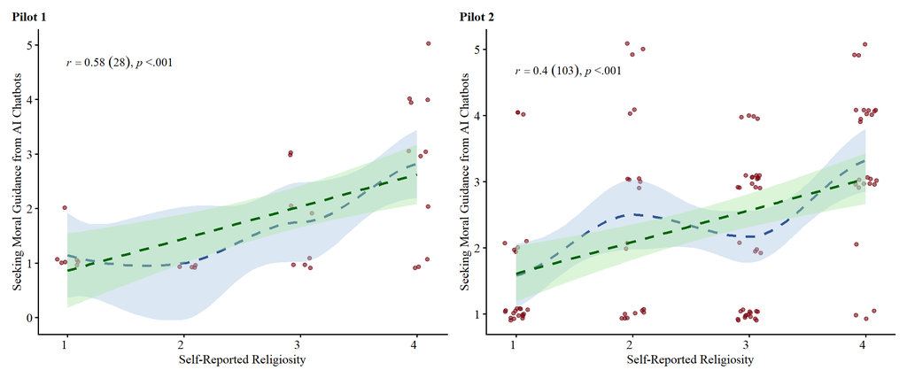

Figure 1: Pilot Studies: Self-Reported Religiosity and Seeking Moral Guidance from AI Chatbots

Table 6: Pilot Studies: Self-Reported Religiosity Predicting Seeking Moral Guidance From AI Chatbots

| Study | Model 1 β | Model 1 SE | Model 1 95% CI LL | Model 1 95% CI UL | Model 1 p | Model 2 β | Model 2 SE | Model 2 95% CI LL | Model 2 95% CI UL | Model 2 p |
| --- | --- | --- | --- | --- | --- | --- | --- | --- | --- | --- |
| Pilot 1 | 0.58 | 0.15 | 0.26 | 0.89 | < .001 | 0.43 | 0.20 | 0.02 | 0.85 | 0.041 |
| Pilot 2 | 0.40 | 0.09 | 0.22 | 0.57 | < .001 | 0.28 | 0.09 | 0.09 | 0.46 | 0.004 |

# 5 Sources of Moral Advice

## 5.1 Source Ranking Plots

### 5.1.1 Frequency of Seeking Moral Advice

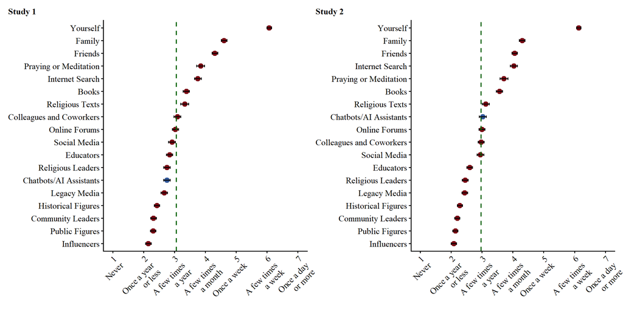

Figure 2: Frequency of Seeking Moral Advice by Source

### 5.1.2 Interest in Seeking Moral Advice

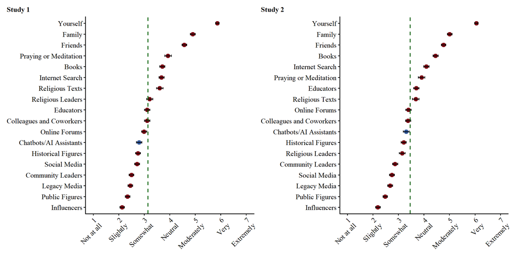

Figure 3: Interest in Seeking Moral Advice by Source

### 5.1.3 Accessibility of Moral Advice Sources (Study 2 Only)

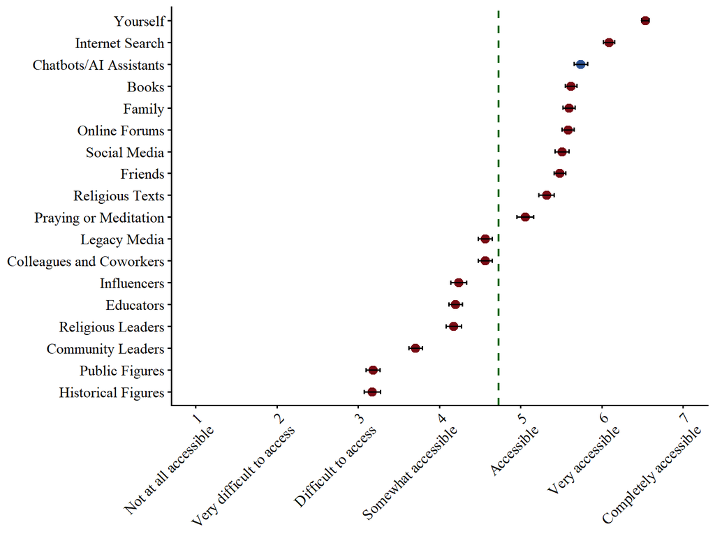

Figure 4: Study 2: Accessibility of Each Source of Moral Advice

## 5.2 Source Correlation Heatmaps

### 5.2.1 Frequency of Seeking Moral Advice

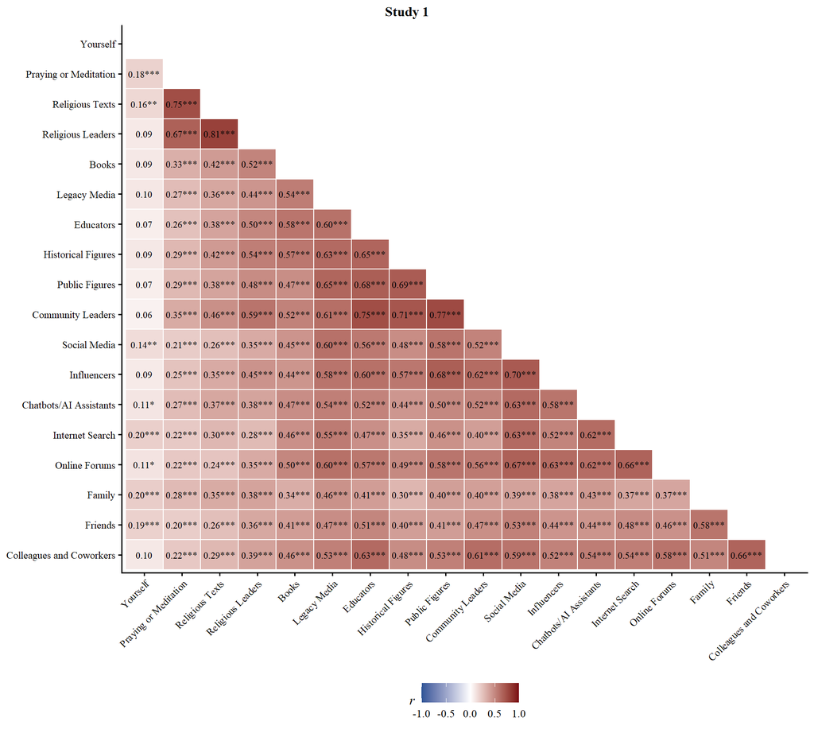

Figure 5: Study 1: Correlation Heatmap — Frequency of Seeking Moral Advice Across Sources

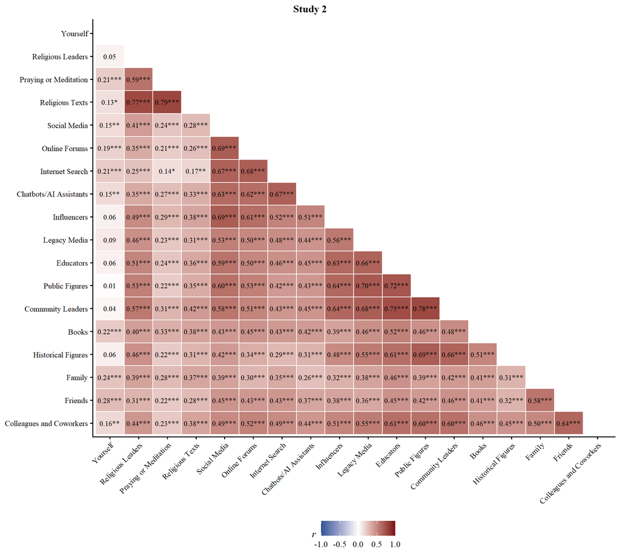

Figure 6: Study 2: Correlation Heatmap — Frequency of Seeking Moral Advice Across Sources

### 5.2.2 Interest in Seeking Moral Advice

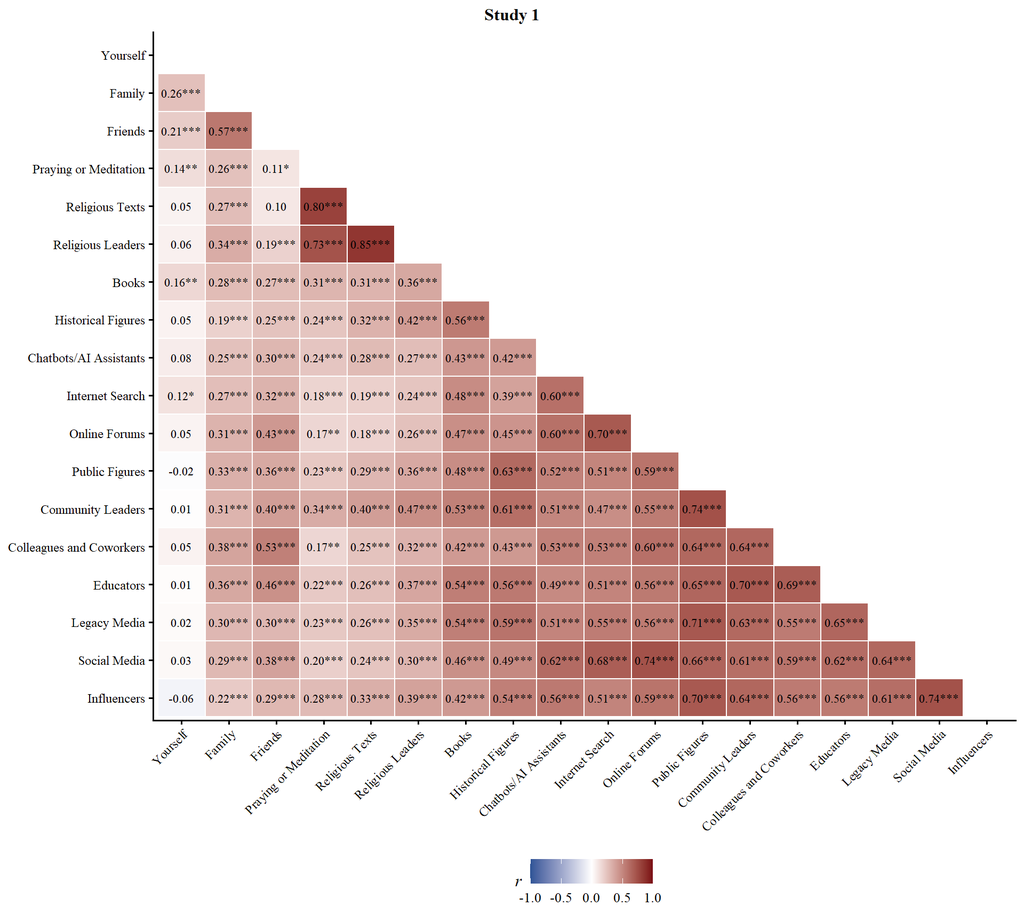

Figure 7: Study 1: Correlation Heatmap — Interest in Seeking Moral Advice Across Sources

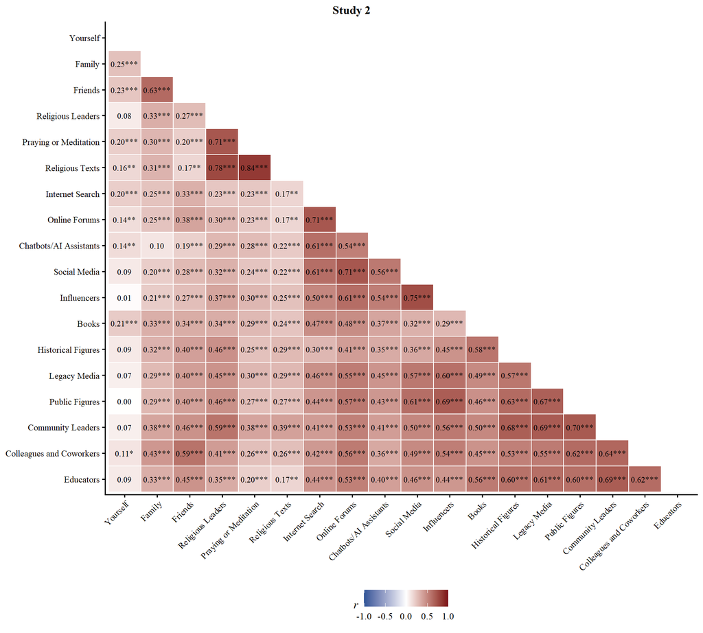

Figure 8: Study 2: Correlation Heatmap — Interest in Seeking Moral Advice Across Sources

# 6 Study Variable Correlation Analysis

## 6.1 Correlation Tables

Table 7: Study 1: Pearson Correlations Between Study Variables

| Variable | Frequency of Seeking Moral Advice from AI Chatbots | Interest in Seeking Moral Advice from AI Chatbots | Overall Frequency of Seeking Moral Advice | Overall Interest in Seeking Moral Advice | General Open-Mindedness | Open-Mindedness on Moral Issues | Intellectual Humility (CIHS) | Intellectual Humility (MMIH) | Belief in Moral Objectivity | Perceived Valence of AI Chatbots as Moral Advisors | Perceived Authority of AI Chatbots as Moral Advisors | Self-Reported Religiosity | Religious Behavior Score | Age | Education | Income | Socioeconomic Status | Political Orientation |
| --- | --- | --- | --- | --- | --- | --- | --- | --- | --- | --- | --- | --- | --- | --- | --- | --- | --- | --- |
| Frequency of Seeking Moral Advice from AI Chatbots | — |  |  |  |  |  |  |  |  |  |  |  |  |  |  |  |  |  |
| Interest in Seeking Moral Advice from AI Chatbots | 0.80*** [0.76, 0.83] | — |  |  |  |  |  |  |  |  |  |  |  |  |  |  |  |  |
| Overall Frequency of Seeking Moral Advice | 0.70*** [0.64, 0.75] | 0.63*** [0.56, 0.69] | — |  |  |  |  |  |  |  |  |  |  |  |  |  |  |  |
| Overall Interest in Seeking Moral Advice | 0.63*** [0.56, 0.69] | 0.66*** [0.60, 0.72] | 0.88*** [0.86, 0.90] | — |  |  |  |  |  |  |  |  |  |  |  |  |  |  |
| General Open-Mindedness | 0.38*** [0.29, 0.47] | 0.35*** [0.25, 0.44] | 0.47*** [0.38, 0.55] | 0.47*** [0.38, 0.55] | — |  |  |  |  |  |  |  |  |  |  |  |  |  |
| Open-Mindedness on Moral Issues | 0.33*** [0.23, 0.42] | 0.31*** [0.21, 0.40] | 0.48*** [0.39, 0.56] | 0.52*** [0.44, 0.59] | 0.57*** [0.49, 0.64] | — |  |  |  |  |  |  |  |  |  |  |  |  |
| Intellectual Humility (CIHS) | -0.11* [-0.21, -0.01] | -0.14** [-0.24, -0.04] | -0.15** [-0.25, -0.05] | -0.07 [-0.17, 0.04] | 0.12* [0.02, 0.22] | 0.15** [0.04, 0.25] | — |  |  |  |  |  |  |  |  |  |  |  |
| Intellectual Humility (MMIH) | -0.27*** [-0.36, -0.17] | -0.30*** [-0.39, -0.20] | -0.29*** [-0.39, -0.19] | -0.23*** [-0.33, -0.13] | -0.05 [-0.16, 0.05] | -0.05 [-0.16, 0.05] | 0.73*** [0.68, 0.78] | — |  |  |  |  |  |  |  |  |  |  |
| Belief in Moral Objectivity | 0.09 [-0.01, 0.19] | 0.07 [-0.03, 0.18] | 0.12* [0.01, 0.22] | 0.13* [0.03, 0.23] | 0.11* [0.00, 0.21] | 0.05 [-0.06, 0.15] | -0.13* [-0.23, -0.02] | -0.19*** [-0.29, -0.09] | — |  |  |  |  |  |  |  |  |  |
| Perceived Valence of AI Chatbots as Moral Advisors | 0.47*** [0.39, 0.55] | 0.53*** [0.45, 0.60] | 0.35*** [0.25, 0.44] | 0.36*** [0.26, 0.45] | 0.23*** [0.13, 0.33] | 0.19*** [0.09, 0.29] | -0.01 [-0.12, 0.09] | -0.07 [-0.17, 0.04] | 0.08 [-0.03, 0.18] | — |  |  |  |  |  |  |  |  |
| Perceived Authority of AI Chatbots as Moral Advisors | 0.49*** [0.41, 0.57] | 0.56*** [0.48, 0.63] | 0.40*** [0.31, 0.49] | 0.41*** [0.32, 0.49] | 0.25*** [0.15, 0.35] | 0.22*** [0.12, 0.32] | -0.10 [-0.21, 0.00] | -0.18*** [-0.28, -0.08] | 0.11* [0.01, 0.21] | 0.78*** [0.74, 0.82] | — |  |  |  |  |  |  |  |
| Self-Reported Religiosity | 0.21*** [0.11, 0.31] | 0.18*** [0.08, 0.28] | 0.27*** [0.17, 0.37] | 0.24*** [0.14, 0.34] | 0.14** [0.04, 0.24] | 0.09 [-0.02, 0.19] | -0.08 [-0.19, 0.02] | -0.07 [-0.17, 0.04] | 0.28*** [0.18, 0.38] | 0.16** [0.06, 0.26] | 0.19*** [0.09, 0.29] | — |  |  |  |  |  |  |
| Religious Behavior Score | 0.31*** [0.21, 0.40] | 0.28*** [0.18, 0.37] | 0.37*** [0.27, 0.46] | 0.31*** [0.21, 0.40] | 0.23*** [0.13, 0.33] | 0.15** [0.04, 0.25] | -0.04 [-0.15, 0.06] | -0.06 [-0.16, 0.05] | 0.26*** [0.16, 0.35] | 0.26*** [0.16, 0.35] | 0.26*** [0.16, 0.36] | 0.81*** [0.77, 0.84] | — |  |  |  |  |  |
| Age | -0.17** [-0.27, -0.07] | -0.16** [-0.26, -0.05] | -0.14** [-0.24, -0.03] | -0.15** [-0.26, -0.05] | -0.18*** [-0.28, -0.07] | -0.26*** [-0.35, -0.16] | 0.03 [-0.07, 0.14] | 0.09 [-0.01, 0.19] | 0.03 [-0.07, 0.14] | 0.05 [-0.05, 0.16] | -0.02 [-0.12, 0.09] | 0.05 [-0.06, 0.15] | 0.09 [-0.02, 0.19] | — |  |  |  |  |
| Education | 0.22*** [0.12, 0.32] | 0.16** [0.06, 0.26] | 0.28*** [0.18, 0.38] | 0.25*** [0.15, 0.35] | 0.27*** [0.17, 0.36] | 0.21*** [0.10, 0.30] | 0.03 [-0.08, 0.13] | -0.01 [-0.12, 0.10] | 0.09 [-0.01, 0.20] | 0.08 [-0.03, 0.18] | 0.08 [-0.02, 0.19] | 0.08 [-0.02, 0.18] | 0.21*** [0.11, 0.31] | 0.15** [0.05, 0.25] | — |  |  |  |
| Income | 0.10 [-0.01, 0.20] | 0.08 [-0.02, 0.19] | 0.19*** [0.08, 0.29] | 0.16** [0.06, 0.26] | 0.09 [-0.01, 0.20] | 0.04 [-0.07, 0.14] | 0.01 [-0.10, 0.11] | 0.02 [-0.09, 0.12] | 0.03 [-0.08, 0.13] | -0.00 [-0.11, 0.10] | 0.05 [-0.06, 0.15] | 0.10 [-0.01, 0.20] | 0.15** [0.05, 0.25] | 0.02 [-0.08, 0.13] | 0.34*** [0.25, 0.43] | — |  |  |
| Socioeconomic Status | 0.19*** [0.08, 0.29] | 0.22*** [0.12, 0.32] | 0.30*** [0.20, 0.40] | 0.30*** [0.20, 0.39] | 0.20*** [0.10, 0.30] | 0.10 [-0.01, 0.20] | -0.08 [-0.18, 0.03] | -0.10 [-0.20, 0.01] | 0.16** [0.06, 0.26] | 0.08 [-0.02, 0.19] | 0.16** [0.05, 0.26] | 0.24*** [0.13, 0.33] | 0.30*** [0.20, 0.39] | 0.05 [-0.05, 0.16] | 0.42*** [0.33, 0.50] | 0.53*** [0.45, 0.60] | — |  |
| Political Orientation | 0.11* [0.00, 0.21] | 0.12* [0.01, 0.22] | 0.12* [0.02, 0.23] | 0.09 [-0.02, 0.19] | -0.03 [-0.14, 0.07] | -0.06 [-0.16, 0.05] | -0.17** [-0.27, -0.06] | -0.11* [-0.21, -0.01] | 0.18*** [0.08, 0.28] | 0.14** [0.04, 0.24] | 0.10 [-0.01, 0.20] | 0.49*** [0.41, 0.57] | 0.50*** [0.41, 0.57] | 0.10 [-0.01, 0.20] | 0.06 [-0.05, 0.16] | 0.17** [0.07, 0.27] | 0.22*** [0.12, 0.32] | — |

Table 8: Study 2: Pearson Correlations Between Study Variables

| Variable | Frequency of Seeking Moral Advice from AI Chatbots | Interest in Seeking Moral Advice from AI Chatbots | Access to AI Chatbots as Moral Advisors | Overall Frequency of Seeking Moral Advice | Overall Interest in Seeking Moral Advice | Overall Access to Sources of Moral Advice | Open-Mindedness on Moral Issues | Belief in Moral Objectivity | Perceived Authority of AI Chatbots as Moral Advisors | Tendency to Anthropomorphize AI Chatbots | Fear of Negative Judgement | Self-Reflective Tendencies | Deference to Authority (MFQ-2) | Deference to Authority (MAC-Q) | Self-Reported Religiosity | Religious Behavior Score | Age | Education | Political Orientation | Socioeconomic Status | Income |
| --- | --- | --- | --- | --- | --- | --- | --- | --- | --- | --- | --- | --- | --- | --- | --- | --- | --- | --- | --- | --- | --- |
| Frequency of Seeking Moral Advice from AI Chatbots | — |  |  |  |  |  |  |  |  |  |  |  |  |  |  |  |  |  |  |  |  |
| Interest in Seeking Moral Advice from AI Chatbots | 0.84*** [0.81, 0.87] | — |  |  |  |  |  |  |  |  |  |  |  |  |  |  |  |  |  |  |  |
| Access to AI Chatbots as Moral Advisors | 0.32*** [0.22, 0.41] | 0.34*** [0.25, 0.43] | — |  |  |  |  |  |  |  |  |  |  |  |  |  |  |  |  |  |  |
| Overall Frequency of Seeking Moral Advice | 0.64*** [0.57, 0.69] | 0.51*** [0.43, 0.59] | 0.20*** [0.10, 0.30] | — |  |  |  |  |  |  |  |  |  |  |  |  |  |  |  |  |  |
| Overall Interest in Seeking Moral Advice | 0.55*** [0.48, 0.62] | 0.57*** [0.49, 0.63] | 0.24*** [0.14, 0.34] | 0.84*** [0.80, 0.86] | — |  |  |  |  |  |  |  |  |  |  |  |  |  |  |  |  |
| Overall Access to Sources of Moral Advice | 0.23*** [0.13, 0.33] | 0.25*** [0.14, 0.34] | 0.50*** [0.41, 0.57] | 0.44*** [0.35, 0.52] | 0.50*** [0.42, 0.57] | — |  |  |  |  |  |  |  |  |  |  |  |  |  |  |  |
| Open-Mindedness on Moral Issues | 0.38*** [0.29, 0.47] | 0.36*** [0.27, 0.45] | 0.11* [0.01, 0.22] | 0.47*** [0.38, 0.55] | 0.47*** [0.39, 0.55] | 0.26*** [0.16, 0.36] | — |  |  |  |  |  |  |  |  |  |  |  |  |  |  |
| Belief in Moral Objectivity | 0.14** [0.03, 0.24] | 0.15** [0.05, 0.25] | 0.08 [-0.03, 0.18] | 0.08 [-0.02, 0.19] | 0.10 [-0.00, 0.21] | 0.12* [0.02, 0.22] | 0.02 [-0.08, 0.13] | — |  |  |  |  |  |  |  |  |  |  |  |  |  |
| Perceived Authority of AI Chatbots as Moral Advisors | 0.64*** [0.57, 0.70] | 0.72*** [0.67, 0.77] | 0.32*** [0.22, 0.41] | 0.39*** [0.30, 0.48] | 0.40*** [0.30, 0.48] | 0.22*** [0.12, 0.32] | 0.31*** [0.21, 0.40] | 0.15** [0.04, 0.25] | — |  |  |  |  |  |  |  |  |  |  |  |  |
| Tendency to Anthropomorphize AI Chatbots | 0.44*** [0.35, 0.52] | 0.49*** [0.41, 0.57] | 0.17** [0.07, 0.28] | 0.31*** [0.21, 0.40] | 0.30*** [0.20, 0.40] | 0.13* [0.02, 0.23] | 0.30*** [0.20, 0.39] | 0.18*** [0.08, 0.28] | 0.57*** [0.49, 0.64] | — |  |  |  |  |  |  |  |  |  |  |  |
| Fear of Negative Judgement | 0.05 [-0.05, 0.16] | 0.02 [-0.08, 0.13] | 0.04 [-0.07, 0.14] | 0.09 [-0.02, 0.19] | 0.07 [-0.03, 0.18] | -0.06 [-0.17, 0.04] | 0.07 [-0.04, 0.17] | -0.07 [-0.18, 0.03] | -0.03 [-0.13, 0.08] | -0.02 [-0.13, 0.09] | — |  |  |  |  |  |  |  |  |  |  |
| Self-Reflective Tendencies | 0.17** [0.07, 0.27] | 0.20*** [0.10, 0.30] | 0.17** [0.06, 0.27] | 0.24*** [0.13, 0.33] | 0.30*** [0.20, 0.39] | 0.15** [0.05, 0.26] | 0.40*** [0.30, 0.48] | 0.03 [-0.08, 0.13] | 0.14** [0.03, 0.24] | 0.12* [0.02, 0.22] | 0.13* [0.03, 0.23] | — |  |  |  |  |  |  |  |  |  |
| Deference to Authority (MFQ-2) | 0.32*** [0.22, 0.41] | 0.30*** [0.20, 0.40] | 0.20*** [0.09, 0.30] | 0.35*** [0.25, 0.44] | 0.34*** [0.24, 0.43] | 0.27*** [0.17, 0.36] | 0.17** [0.07, 0.27] | 0.34*** [0.25, 0.43] | 0.27*** [0.17, 0.36] | 0.32*** [0.22, 0.41] | -0.12* [-0.22, -0.02] | 0.04 [-0.06, 0.15] | — |  |  |  |  |  |  |  |  |
| Deference to Authority (MAC-Q) | 0.31*** [0.21, 0.40] | 0.34*** [0.24, 0.43] | 0.16** [0.05, 0.26] | 0.37*** [0.27, 0.45] | 0.38*** [0.28, 0.47] | 0.20*** [0.10, 0.30] | 0.23*** [0.12, 0.32] | 0.21*** [0.11, 0.31] | 0.32*** [0.22, 0.41] | 0.36*** [0.26, 0.45] | 0.03 [-0.08, 0.13] | 0.11* [0.00, 0.21] | 0.64*** [0.57, 0.70] | — |  |  |  |  |  |  |  |
| Self-Reported Religiosity | 0.27*** [0.17, 0.37] | 0.21*** [0.11, 0.31] | 0.19*** [0.08, 0.29] | 0.32*** [0.22, 0.41] | 0.29*** [0.19, 0.38] | 0.30*** [0.20, 0.40] | 0.08 [-0.02, 0.19] | 0.36*** [0.26, 0.45] | 0.17** [0.07, 0.27] | 0.16** [0.06, 0.26] | -0.06 [-0.16, 0.05] | 0.10 [-0.00, 0.20] | 0.51*** [0.43, 0.58] | 0.28*** [0.18, 0.37] | — |  |  |  |  |  |  |
| Religious Behavior Score | 0.33*** [0.23, 0.42] | 0.23*** [0.13, 0.33] | 0.16** [0.06, 0.26] | 0.37*** [0.27, 0.45] | 0.30*** [0.21, 0.40] | 0.28*** [0.18, 0.37] | 0.12* [0.01, 0.22] | 0.31*** [0.22, 0.41] | 0.17** [0.07, 0.28] | 0.22*** [0.12, 0.32] | -0.06 [-0.16, 0.05] | 0.07 [-0.04, 0.17] | 0.53*** [0.46, 0.61] | 0.32*** [0.23, 0.41] | 0.85*** [0.81, 0.87] | — |  |  |  |  |  |
| Age | -0.15** [-0.25, -0.05] | -0.09 [-0.19, 0.02] | -0.14** [-0.25, -0.04] | -0.23*** [-0.33, -0.13] | -0.20*** [-0.30, -0.10] | -0.06 [-0.16, 0.05] | -0.20*** [-0.30, -0.10] | 0.10 [-0.00, 0.21] | -0.11* [-0.22, -0.01] | 0.07 [-0.03, 0.18] | -0.30*** [-0.39, -0.20] | -0.15** [-0.25, -0.04] | 0.11* [0.00, 0.21] | 0.01 [-0.09, 0.12] | 0.01 [-0.10, 0.12] | 0.02 [-0.09, 0.12] | — |  |  |  |  |
| Education | 0.12* [0.01, 0.22] | 0.08 [-0.03, 0.18] | 0.03 [-0.07, 0.14] | 0.18*** [0.07, 0.28] | 0.15** [0.05, 0.25] | 0.17** [0.07, 0.27] | 0.05 [-0.05, 0.16] | -0.00 [-0.11, 0.10] | 0.11* [0.01, 0.21] | -0.03 [-0.14, 0.07] | -0.12* [-0.22, -0.01] | 0.02 [-0.09, 0.12] | 0.00 [-0.10, 0.11] | -0.03 [-0.13, 0.08] | 0.06 [-0.04, 0.17] | 0.11* [0.01, 0.21] | 0.01 [-0.10, 0.11] | — |  |  |  |
| Political Orientation | 0.21*** [0.11, 0.31] | 0.18*** [0.08, 0.28] | 0.08 [-0.03, 0.18] | 0.17** [0.07, 0.27] | 0.11* [0.01, 0.22] | 0.11* [0.01, 0.22] | 0.04 [-0.07, 0.14] | 0.27*** [0.17, 0.37] | 0.20*** [0.09, 0.29] | 0.18*** [0.08, 0.28] | -0.08 [-0.18, 0.03] | -0.08 [-0.18, 0.03] | 0.63*** [0.56, 0.69] | 0.42*** [0.33, 0.51] | 0.46*** [0.38, 0.54] | 0.48*** [0.39, 0.56] | 0.04 [-0.07, 0.14] | 0.02 [-0.09, 0.12] | — |  |  |
| Socioeconomic Status | 0.16** [0.05, 0.26] | 0.10 [-0.01, 0.20] | 0.02 [-0.09, 0.12] | 0.25*** [0.15, 0.35] | 0.20*** [0.09, 0.30] | 0.21*** [0.11, 0.31] | 0.16** [0.06, 0.26] | 0.10 [-0.00, 0.21] | 0.15** [0.04, 0.25] | 0.09 [-0.02, 0.19] | -0.12* [-0.23, -0.02] | 0.06 [-0.04, 0.17] | 0.19*** [0.08, 0.29] | 0.13* [0.03, 0.24] | 0.12* [0.02, 0.23] | 0.21*** [0.11, 0.31] | -0.01 [-0.11, 0.10] | 0.47*** [0.38, 0.55] | 0.18*** [0.08, 0.28] | — |  |
| Income | 0.10 [-0.01, 0.20] | 0.02 [-0.08, 0.13] | 0.13* [0.03, 0.23] | 0.15** [0.04, 0.25] | 0.13* [0.02, 0.23] | 0.19*** [0.08, 0.29] | 0.10 [-0.00, 0.20] | -0.00 [-0.11, 0.11] | 0.07 [-0.04, 0.17] | -0.02 [-0.13, 0.08] | -0.02 [-0.12, 0.09] | 0.05 [-0.05, 0.16] | 0.06 [-0.04, 0.17] | 0.06 [-0.05, 0.16] | 0.04 [-0.07, 0.14] | 0.12* [0.02, 0.22] | -0.01 [-0.11, 0.10] | 0.44*** [0.35, 0.52] | 0.06 [-0.05, 0.16] | 0.57*** [0.50, 0.64] | — |

## 6.2 Correlation Heatmaps

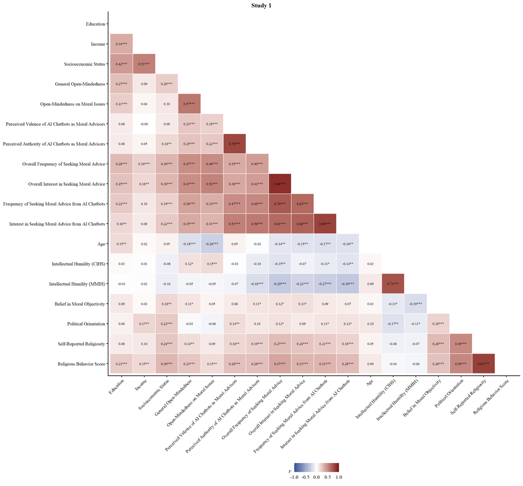

Figure 9: Study 1: Correlation Heatmap — Study Variables

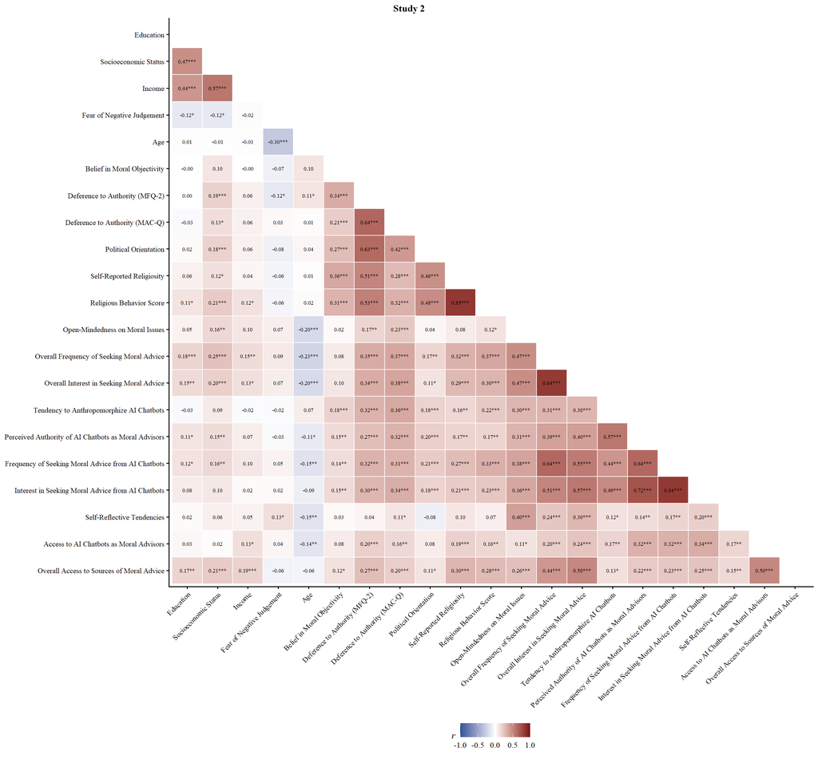

Figure 10: Study 2: Correlation Heatmap — Study Variables

# 7 Correlation Analyses: Predictor → AI Moral Interest

The following analyses examine the two supplementary predictor–outcome relationships not covered in the main body: Religious Behavior Score → Interest and Self-Reported Religiosity → Interest. Correlations are presented with predictor first, then study.

Table 9: Pearson Correlations Between Religiosity Predictors and Interest in Seeking Moral Advice From AI Chatbots

| Predictor | Study | N | r | t | df | p |
| --- | --- | --- | --- | --- | --- | --- |
| Religious Behavior Score | Study 1 | 348 | 0.28 | 5.32 | 346 | <.001 |
|  | Study 2 | 347 | 0.23 | 4.47 | 345 | <.001 |
| Self-Reported Religiosity | Study 1 | 348 | 0.18 | 3.40 | 346 | <.001 |
|  | Study 2 | 347 | 0.21 | 4.07 | 345 | <.001 |

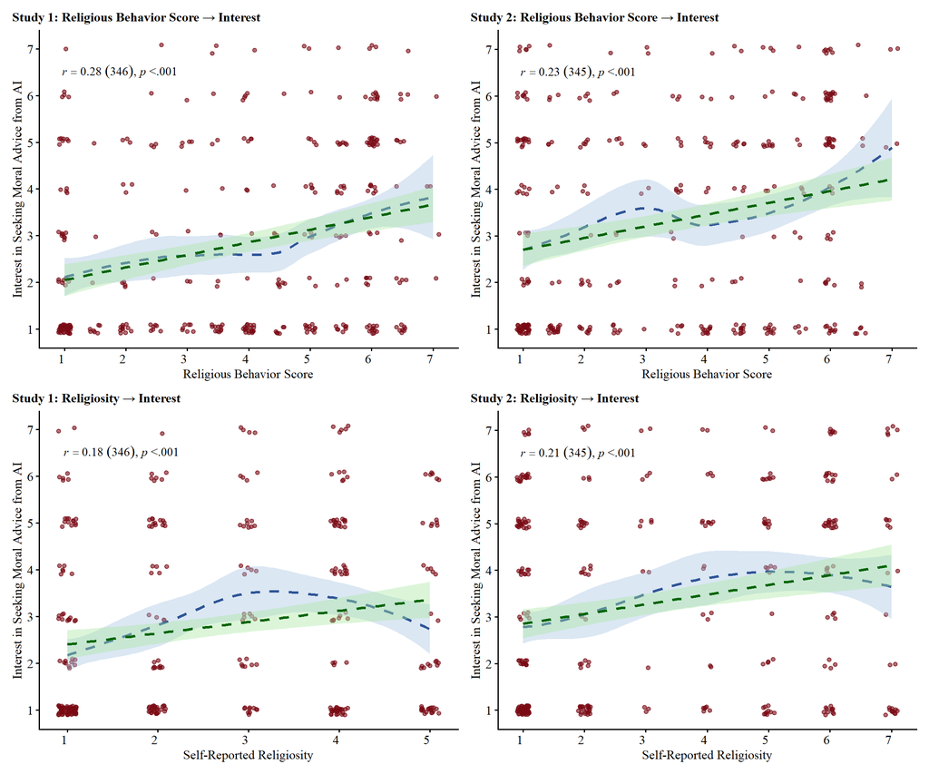

Figure 11: Religious Behavior Score and Self-Reported Religiosity Predicting Interest in Seeking Moral Advice from AI Chatbots

## 7.1 Regression Analyses: Predictor → AI Moral Interest

We report regression analyses for both supplementary outcome models: Religious Behavior Score → Interest and Self-Reported Religiosity → Interest.

### 7.1.1 Religious Behavior Score → AI Moral Interest

Table 10: Religious Behavior Score Predicting Interest in Seeking Moral Advice From AI Chatbots

| Study | Model 1 β | Model 1 SE | Model 1 95% CI LL | Model 1 95% CI UL | Model 1 p | Model 2 β | Model 2 SE | Model 2 95% CI LL | Model 2 95% CI UL | Model 2 p |
| --- | --- | --- | --- | --- | --- | --- | --- | --- | --- | --- |
| Study 1 | 0.28 | 0.05 | 0.17 | 0.38 | < .001 | 0.25 | 0.06 | 0.13 | 0.37 | < .001 |
| Study 2 | 0.23 | 0.05 | 0.13 | 0.34 | < .001 | 0.18 | 0.06 | 0.06 | 0.30 | 0.003 |

### 7.1.2 Self-Reported Religiosity → AI Moral Interest

Table 11: Self-Reported Religiosity Predicting Interest in Seeking Moral Advice From AI Chatbots

| Study | Model 1 β | Model 1 SE | Model 1 95% CI LL | Model 1 95% CI UL | Model 1 p | Model 2 β | Model 2 SE | Model 2 95% CI LL | Model 2 95% CI UL | Model 2 p |
| --- | --- | --- | --- | --- | --- | --- | --- | --- | --- | --- |
| Study 1 | 0.18 | 0.05 | 0.08 | 0.28 | < .001 | 0.13 | 0.06 | 0.01 | 0.25 | 0.027 |
| Study 2 | 0.21 | 0.05 | 0.11 | 0.32 | < .001 | 0.16 | 0.06 | 0.04 | 0.27 | 0.008 |

# 8 Mediation Analyses

## 8.1 Regression Analyses: Predictor → Mediators

### 8.1.1 Self-Reported Religiosity → Mediators

The following tables report the regression of Self-Reported Religiosity onto each candidate mediator. These results underlie both the Self-Reported Religiosity → Frequency and Self-Reported Religiosity → Interest mediation pathways, as the Religiosity → Mediator path is identical across both.

Table 12: Study 1: Self-Reported Religiosity Predicting Each Mediator

| Mediator | Model 1 β | Model 1 SE | Model 1 95% CI LL | Model 1 95% CI UL | Model 1 p | Model 1 Sig (Corrected) | Model 2 β | Model 2 SE | Model 2 95% CI LL | Model 2 95% CI UL | Model 2 p | Model 2 Sig (Corrected) |
| --- | --- | --- | --- | --- | --- | --- | --- | --- | --- | --- | --- | --- |
| Overall Frequency of Seeking Moral Advice | 0.27 | 0.05 | 0.17 | 0.37 | < .001 | Yes | 0.23 | 0.06 | 0.11 | 0.34 | < .001 | Yes |
| Overall Interest in Seeking Moral Advice | 0.24 | 0.05 | 0.14 | 0.34 | < .001 | Yes | 0.21 | 0.06 | 0.10 | 0.32 | < .001 | Yes |
| General Open-Mindedness | 0.14 | 0.05 | 0.04 | 0.25 | 0.008 | No | 0.17 | 0.06 | 0.05 | 0.28 | 0.004 | Yes |
| Open-Mindedness on Moral Issues | 0.09 | 0.05 | -0.02 | 0.19 | 0.099 | No | 0.13 | 0.06 | 0.01 | 0.24 | 0.029 | No |
| Intellectual Humility (CIHS) | -0.08 | 0.05 | -0.19 | 0.02 | 0.127 | No | 0.01 | 0.06 | -0.11 | 0.13 | 0.847 | No |
| Intellectual Humility (MMIH) | -0.07 | 0.05 | -0.17 | 0.04 | 0.197 | No | -0.00 | 0.06 | -0.13 | 0.12 | 0.940 | No |
| Belief in Moral Objectivity | 0.28 | 0.05 | 0.18 | 0.39 | < .001 | Yes | 0.23 | 0.06 | 0.11 | 0.35 | < .001 | Yes |
| Perceived Valence of AI Chatbots as Moral Advisors | 0.16 | 0.05 | 0.06 | 0.27 | 0.002 | Yes | 0.10 | 0.06 | -0.02 | 0.22 | 0.104 | No |
| Perceived Authority of AI Chatbots as Moral Advisors | 0.19 | 0.05 | 0.09 | 0.30 | < .001 | Yes | 0.16 | 0.06 | 0.04 | 0.28 | 0.012 | No |

Table 13: Study 2: Self-Reported Religiosity Predicting Each Mediator

| Mediator | Model 1 β | Model 1 SE | Model 1 95% CI LL | Model 1 95% CI UL | Model 1 p | Model 1 Sig (Corrected) | Model 2 β | Model 2 SE | Model 2 95% CI LL | Model 2 95% CI UL | Model 2 p | Model 2 Sig (Corrected) |
| --- | --- | --- | --- | --- | --- | --- | --- | --- | --- | --- | --- | --- |
| Overall Frequency of Seeking Moral Advice | 0.32 | 0.05 | 0.22 | 0.42 | < .001 | Yes | 0.29 | 0.05 | 0.18 | 0.40 | < .001 | Yes |
| Overall Interest in Seeking Moral Advice | 0.29 | 0.05 | 0.19 | 0.39 | < .001 | Yes | 0.29 | 0.06 | 0.17 | 0.40 | < .001 | Yes |
| Open-Mindedness on Moral Issues | 0.08 | 0.05 | -0.02 | 0.19 | 0.126 | No | 0.08 | 0.06 | -0.04 | 0.19 | 0.204 | No |
| Belief in Moral Objectivity | 0.36 | 0.05 | 0.26 | 0.46 | < .001 | Yes | 0.30 | 0.06 | 0.19 | 0.41 | < .001 | Yes |
| Perceived Authority of AI Chatbots as Moral Advisors | 0.17 | 0.05 | 0.07 | 0.28 | 0.001 | Yes | 0.09 | 0.06 | -0.02 | 0.21 | 0.112 | No |
| Tendency to Anthropomorphize AI Chatbots | 0.16 | 0.05 | 0.06 | 0.27 | 0.003 | Yes | 0.10 | 0.06 | -0.02 | 0.22 | 0.101 | No |
| Fear of Negative Judgement | -0.06 | 0.05 | -0.16 | 0.05 | 0.272 | No | -0.02 | 0.06 | -0.14 | 0.09 | 0.692 | No |
| Self-Reflective Tendencies | 0.10 | 0.05 | -0.00 | 0.21 | 0.061 | No | 0.17 | 0.06 | 0.05 | 0.29 | 0.004 | Yes |
| Deference to Authority (MFQ-2) | 0.51 | 0.05 | 0.42 | 0.60 | < .001 | Yes | 0.28 | 0.04 | 0.19 | 0.37 | < .001 | Yes |
| Deference to Authority (MAC-Q) | 0.28 | 0.05 | 0.18 | 0.38 | < .001 | Yes | 0.11 | 0.06 | -0.00 | 0.21 | 0.055 | No |

### 8.1.2 Religious Behavior Score → Mediators

The regression of Religious Behavior Score onto each candidate mediator is reported in the main manuscript (Tables 6 and 7). Because the predictor → mediator path is identical regardless of the downstream outcome, those estimates also underlie the Religious Behavior Score → Interest mediation analyses reported below.

## 8.2 Individual Mediation Analyses

For the individual mediation analyses, candidate mediators were included only if they were significantly associated with the focal predictor (applying the same conservative Bonferroni correction used in the main manuscript: $p < .05 / 9 = .0056$ in Study 1; $p < .05 / 10 = .0050$ in Study 2) in either the simple (Model 1) or demographic-adjusted (Model 2) regression models.

### 8.2.1 Self-Reported Religiosity → Mediator → AI Moral Frequency

Table 14: Study 1: Mediation — Self-Reported Religiosity → Mediator → AI Moral Frequency

| Mediators | Path a X -> M | Path b M -> Y (given X) | Indirect (ab) Effect | Indirect (ab) 95% CI LL | Indirect (ab) 95% CI UL | Direct c' X -> Y (given M) | Full Model Proportion Mediated | Selected for SEM |
| --- | --- | --- | --- | --- | --- | --- | --- | --- |
| Overall Frequency of Seeking Moral Advice | 0.26*** | 1.02*** | 0.26*** | 0.16 | 0.37 | 0.03 | 90.54% | Yes |
| Overall Interest in Seeking Moral Advice | 0.22*** | 0.94*** | 0.21*** | 0.11 | 0.31 | 0.08 | 71.31% | No |
| General Open-Mindedness | 0.84** | 0.08*** | 0.07** | 0.02 | 0.13 | 0.22** | 24.65% | Yes |
| Belief in Moral Objectivity | 5.74*** | 0.00 | 0.01 | -0.03 | 0.06 | 0.28*** | 4.71% | No |
| Perceived Valence of AI Chatbots as Moral Advisors | 0.17** | 0.61*** | 0.10** | 0.04 | 0.18 | 0.19** | 35.72% | No |
| Perceived Authority of AI Chatbots as Moral Advisors | 0.21*** | 0.59*** | 0.13*** | 0.06 | 0.20 | 0.16* | 43.59% | Yes |

Table 15: Study 2: Mediation — Self-Reported Religiosity → Mediator → AI Moral Frequency

| Mediators | Path a X -> M | Path b M -> Y (given X) | Indirect (ab) Effect | Indirect (ab) 95% CI LL | Indirect (ab) 95% CI UL | Direct c' X -> Y (given M) | Full Model Proportion Mediated | Selected for SEM |
| --- | --- | --- | --- | --- | --- | --- | --- | --- |
| Overall Frequency of Seeking Moral Advice | 0.19*** | 1.02*** | 0.19*** | 0.13 | 0.26 | 0.07 | 72.27% | Yes |
| Overall Interest in Seeking Moral Advice | 0.17*** | 0.85*** | 0.15*** | 0.09 | 0.21 | 0.12** | 54.83% | No |
| Belief in Moral Objectivity | 0.31*** | 0.05 | 0.02 | -0.02 | 0.06 | 0.25*** | 6.22% | No |
| Perceived Authority of AI Chatbots as Moral Advisors | 0.14** | 0.73*** | 0.10** | 0.04 | 0.17 | 0.16*** | 38.74% | Yes |
| Tendency to Anthropomorphize AI Chatbots | 0.08** | 0.82*** | 0.06** | 0.02 | 0.11 | 0.20*** | 24.13% | Yes |
| Self-Reflective Tendencies | 0.60 | 0.02** | 0.01* | 0.00 | 0.03 | 0.25*** | 5.47% | No |
| Deference to Authority (MFQ-2) | 1.53*** | 0.08*** | 0.12*** | 0.06 | 0.19 | 0.15* | 45.11% | Yes |
| Deference to Authority (MAC-Q) | 10.42*** | 0.01*** | 0.07*** | 0.03 | 0.11 | 0.20*** | 26.25% | No |

### 8.2.2 Religious Behavior Score → Mediator → AI Moral Interest

Table 16: Study 1: Mediation — Religious Behavior Score → Mediator → AI Moral Interest

| Mediators | Path a X -> M | Path b M -> Y (given X) | Indirect (ab) Effect | Indirect (ab) 95% CI LL | Indirect (ab) 95% CI UL | Direct c' X -> Y (given M) | Full Model Proportion Mediated | Selected for SEM |
| --- | --- | --- | --- | --- | --- | --- | --- | --- |
| Overall Frequency of Seeking Moral Advice | 0.26*** | 0.86*** | 0.22*** | 0.16 | 0.29 | 0.05 | 81.64% | Yes |
| Overall Interest in Seeking Moral Advice | 0.21*** | 0.94*** | 0.19*** | 0.12 | 0.27 | 0.08 | 71.46% | No |
| General Open-Mindedness | 1.02*** | 0.07*** | 0.07*** | 0.03 | 0.11 | 0.20*** | 25.65% | Yes |
| Open-Mindedness on Moral Issues | 1.14** | 0.03*** | 0.04** | 0.01 | 0.07 | 0.23*** | 14.71% | No |
| Belief in Moral Objectivity | 3.82*** | 0.00 | 0.00 | -0.03 | 0.03 | 0.27*** | 0.25% | No |
| Perceived Valence of AI Chatbots as Moral Advisors | 0.20*** | 0.64*** | 0.12*** | 0.07 | 0.18 | 0.15** | 46.23% | No |
| Perceived Authority of AI Chatbots as Moral Advisors | 0.21*** | 0.62*** | 0.13*** | 0.08 | 0.19 | 0.14** | 49.59% | Yes |

Table 17: Study 2: Mediation — Religious Behavior Score → Mediator → AI Moral Interest

| Mediators | Path a X -> M | Path b M -> Y (given X) | Indirect (ab) Effect | Indirect (ab) 95% CI LL | Indirect (ab) 95% CI UL | Direct c' X -> Y (given M) | Full Model Proportion Mediated | Selected for SEM |
| --- | --- | --- | --- | --- | --- | --- | --- | --- |
| Overall Frequency of Seeking Moral Advice | 0.24*** | 0.82*** | 0.20*** | 0.13 | 0.26 | 0.06 | 77.30% | Yes |
| Overall Interest in Seeking Moral Advice | 0.20*** | 0.89*** | 0.18*** | 0.11 | 0.24 | 0.07 | 70.98% | No |
| Belief in Moral Objectivity | 0.30*** | 0.10 | 0.03 | -0.01 | 0.07 | 0.22*** | 11.46% | No |
| Perceived Authority of AI Chatbots as Moral Advisors | 0.16** | 0.84*** | 0.13*** | 0.05 | 0.21 | 0.12** | 52.76% | Yes |
| Tendency to Anthropomorphize AI Chatbots | 0.12*** | 0.93*** | 0.11*** | 0.06 | 0.17 | 0.14** | 44.10% | Yes |
| Deference to Authority (MFQ-2) | 1.77*** | 0.08*** | 0.14*** | 0.07 | 0.22 | 0.11 | 56.85% | Yes |
| Deference to Authority (MAC-Q) | 13.40*** | 0.01*** | 0.10*** | 0.06 | 0.16 | 0.15** | 40.22% | No |

### 8.2.3 Self-Reported Religiosity → Mediator → AI Moral Interest

Table 18: Study 1: Mediation — Self-Reported Religiosity → Mediator → AI Moral Interest

| Mediators | Path a X -> M | Path b M -> Y (given X) | Indirect (ab) Effect | Indirect (ab) 95% CI LL | Indirect (ab) 95% CI UL | Direct c' X -> Y (given M) | Full Model Proportion Mediated | Selected for SEM |
| --- | --- | --- | --- | --- | --- | --- | --- | --- |
| Overall Frequency of Seeking Moral Advice | 0.26*** | 0.88*** | 0.23*** | 0.14 | 0.32 | 0.01 | 94.04% | Yes |
| Overall Interest in Seeking Moral Advice | 0.22*** | 0.97*** | 0.21*** | 0.12 | 0.31 | 0.03 | 88.26% | No |
| General Open-Mindedness | 0.84** | 0.07*** | 0.06* | 0.01 | 0.12 | 0.18** | 26.31% | Yes |
| Belief in Moral Objectivity | 5.74*** | 0.00 | 0.01 | -0.03 | 0.05 | 0.23** | 3.79% | No |
| Perceived Valence of AI Chatbots as Moral Advisors | 0.17** | 0.67*** | 0.11** | 0.04 | 0.19 | 0.13* | 47.25% | No |
| Perceived Authority of AI Chatbots as Moral Advisors | 0.21*** | 0.65*** | 0.14*** | 0.06 | 0.22 | 0.10 | 58.19% | Yes |

Table 19: Study 2: Mediation — Self-Reported Religiosity → Mediator → AI Moral Interest

| Mediators | Path a X -> M | Path b M -> Y (given X) | Indirect (ab) Effect | Indirect (ab) 95% CI LL | Indirect (ab) 95% CI UL | Direct c' X -> Y (given M) | Full Model Proportion Mediated | Selected for SEM |
| --- | --- | --- | --- | --- | --- | --- | --- | --- |
| Overall Frequency of Seeking Moral Advice | 0.19*** | 0.82*** | 0.15*** | 0.10 | 0.22 | 0.05 | 74.37% | Yes |
| Overall Interest in Seeking Moral Advice | 0.17*** | 0.90*** | 0.15*** | 0.09 | 0.22 | 0.05 | 73.98% | No |
| Belief in Moral Objectivity | 0.31*** | 0.09 | 0.03 | -0.01 | 0.07 | 0.18** | 14.17% | No |
| Perceived Authority of AI Chatbots as Moral Advisors | 0.14** | 0.85*** | 0.12** | 0.04 | 0.20 | 0.09* | 57.63% | Yes |
| Tendency to Anthropomorphize AI Chatbots | 0.08** | 0.94*** | 0.07** | 0.02 | 0.13 | 0.13** | 35.43% | Yes |
| Self-Reflective Tendencies | 0.60 | 0.03*** | 0.02* | 0.00 | 0.04 | 0.19*** | 8.46% | No |
| Deference to Authority (MFQ-2) | 1.53*** | 0.08*** | 0.13*** | 0.07 | 0.20 | 0.08 | 62.43% | Yes |
| Deference to Authority (MAC-Q) | 10.42*** | 0.01*** | 0.08*** | 0.04 | 0.13 | 0.13* | 39.04% | No |

## 8.3 Parallel Mediation Analyses

### 8.3.1 Primary Parallel Mediation Models (Religious Behavior Score → AI Moral Frequency)

Below, we present the full parameter estimates for the parallel mediation models predicting the frequency of seeking AI moral advice from the Religious Behavior Score. The path diagrams are presented in the main text.

Table 20: Study 1: Full Parameter Estimates — Parallel Mediation (Religious Behavior Score → AI Moral Frequency)

| Path | b | β | SE | 95% CI LL | 95% CI UL | p |
| --- | --- | --- | --- | --- | --- | --- |
| Religious Behavior Score → Overall Frequency of Seeking Moral Advice | 0.256 | 0.369 | 0.035 | 0.186 | 0.325 | <.001 |
| Religious Behavior Score → General Open-Mindedness | 1.015 | 0.234 | 0.237 | 0.544 | 1.473 | <.001 |
| Religious Behavior Score → Perceived Authority of AI Chatbots as Moral Advisors | 0.215 | 0.262 | 0.043 | 0.130 | 0.300 | <.001 |
| Overall Frequency of Seeking Moral Advice → AI Moral Frequency | 0.842 | 0.573 | 0.061 | 0.722 | 0.962 | <.001 |
| General Open-Mindedness → AI Moral Frequency | 0.011 | 0.047 | 0.009 | -0.007 | 0.029 | 0.233 |
| Perceived Authority of AI Chatbots as Moral Advisors → AI Moral Frequency | 0.306 | 0.246 | 0.057 | 0.193 | 0.417 | <.001 |
| Religious Behavior Score → AI Moral Frequency (direct) | 0.023 | 0.023 | 0.041 | -0.056 | 0.102 | 0.567 |
| Overall Frequency of Seeking Moral Advice ~~ General Open-Mindedness | 4.553 | 0.423 | 0.572 | 3.427 | 5.690 | <.001 |
| Overall Frequency of Seeking Moral Advice ~~ Perceived Authority of AI Chatbots as Moral Advisors | 0.691 | 0.342 | 0.117 | 0.459 | 0.918 | <.001 |
| General Open-Mindedness ~~ Perceived Authority of AI Chatbots as Moral Advisors | 2.671 | 0.202 | 0.712 | 1.252 | 4.025 | <.001 |
| Indirect via Overall Frequency of Seeking Moral Advice | 0.216 | 0.211 | 0.034 | 0.151 | 0.286 | <.001 |
| Indirect via General Open-Mindedness | 0.011 | 0.011 | 0.010 | -0.008 | 0.032 | 0.267 |
| Indirect via Perceived Authority of AI Chatbots as Moral Advisors | 0.066 | 0.064 | 0.019 | 0.033 | 0.107 | <.001 |
| Total indirect effect | 0.293 | 0.286 | 0.042 | 0.212 | 0.376 | <.001 |

Table 21: Study 2: Full Parameter Estimates — Parallel Mediation (Religious Behavior Score → AI Moral Frequency)

| Path | b | β | SE | 95% CI LL | 95% CI UL | p |
| --- | --- | --- | --- | --- | --- | --- |
| Religious Behavior Score → Overall Frequency of Seeking Moral Advice | 0.239 | 0.367 | 0.034 | 0.172 | 0.305 | <.001 |
| Religious Behavior Score → Perceived Authority of AI Chatbots as Moral Advisors | 0.158 | 0.175 | 0.048 | 0.061 | 0.251 | 0.001 |
| Religious Behavior Score → Tendency to Anthropomorphize AI Chatbots | 0.120 | 0.223 | 0.030 | 0.061 | 0.178 | <.001 |
| Religious Behavior Score → Deference to Authority (MFQ-2) | 1.775 | 0.535 | 0.143 | 1.495 | 2.055 | <.001 |
| Overall Frequency of Seeking Moral Advice → AI Moral Frequency | 0.702 | 0.422 | 0.070 | 0.565 | 0.845 | <.001 |
| Perceived Authority of AI Chatbots as Moral Advisors → AI Moral Frequency | 0.515 | 0.431 | 0.060 | 0.397 | 0.633 | <.001 |
| Tendency to Anthropomorphize AI Chatbots → AI Moral Frequency | 0.095 | 0.047 | 0.093 | -0.086 | 0.284 | 0.305 |
| Deference to Authority (MFQ-2) → AI Moral Frequency | -0.004 | -0.011 | 0.014 | -0.031 | 0.025 | 0.799 |
| Religious Behavior Score → AI Moral Frequency (direct) | 0.103 | 0.096 | 0.050 | 0.006 | 0.201 | 0.037 |
| Overall Frequency of Seeking Moral Advice ~~ Perceived Authority of AI Chatbots as Moral Advisors | 0.756 | 0.355 | 0.122 | 0.515 | 0.990 | <.001 |
| Overall Frequency of Seeking Moral Advice ~~ Tendency to Anthropomorphize AI Chatbots | 0.312 | 0.249 | 0.075 | 0.166 | 0.459 | <.001 |
| Overall Frequency of Seeking Moral Advice ~~ Deference to Authority (MFQ-2) | 1.292 | 0.193 | 0.367 | 0.587 | 2.017 | <.001 |
| Perceived Authority of AI Chatbots as Moral Advisors ~~ Tendency to Anthropomorphize AI Chatbots | 1.017 | 0.552 | 0.104 | 0.810 | 1.214 | <.001 |
| Perceived Authority of AI Chatbots as Moral Advisors ~~ Deference to Authority (MFQ-2) | 2.058 | 0.208 | 0.564 | 0.931 | 3.161 | <.001 |
| Tendency to Anthropomorphize AI Chatbots ~~ Deference to Authority (MFQ-2) | 1.398 | 0.241 | 0.345 | 0.726 | 2.077 | <.001 |
| Indirect via Overall Frequency of Seeking Moral Advice | 0.167 | 0.155 | 0.030 | 0.112 | 0.229 | <.001 |
| Indirect via Perceived Authority of AI Chatbots as Moral Advisors | 0.081 | 0.075 | 0.026 | 0.031 | 0.134 | 0.002 |
| Indirect via Tendency to Anthropomorphize AI Chatbots | 0.011 | 0.011 | 0.012 | -0.010 | 0.038 | 0.339 |
| Indirect via Deference to Authority (MFQ-2) | -0.006 | -0.006 | 0.025 | -0.055 | 0.045 | 0.800 |
| Total indirect effect | 0.254 | 0.235 | 0.052 | 0.154 | 0.357 | <.001 |

### 8.3.2 Supplementary Parallel Mediation Models

To examine the unique contribution of each mediator while accounting for their intercorrelations, we estimated parallel mediation models for all three supplementary predictor–outcome combinations using structural equation modeling with the *lavaan* package in R (Rosseel 2012).

For each combination, we applied a three-step selection procedure to choose the final set of mediators, same as in the primary model. First, we restricted candidates to mediators significantly predicted by the predictor under the Bonferroni-corrected threshold ($p < .05 / 9 = .0056$ in Study 1; $p < .05 / 10 = .0050$ in Study 2) in either the simple or demographic-adjusted models. Second, we further restricted candidates to those with a significant bootstrap indirect effect ($a \times b$ path) at $p < .05$ in the individual mediation analyses. Finally, to minimize multicollinearity and redundancy among multiple mediators within the same conceptual cluster, we selected exactly one representative mediator per cluster. The representative selected was the mediator that accounted for the largest proportion of mediated variance (calculated as $|a \times b \,/\, \text{total effect}|$) from the individual mediation bootstrap simulations.

All included mediators in a model were allowed to intercorrelate, and specific indirect effects were estimated using 5,000 bootstrap resamples.

### 8.3.3 Self-Reported Religiosity → AI Moral Frequency — Path Diagrams

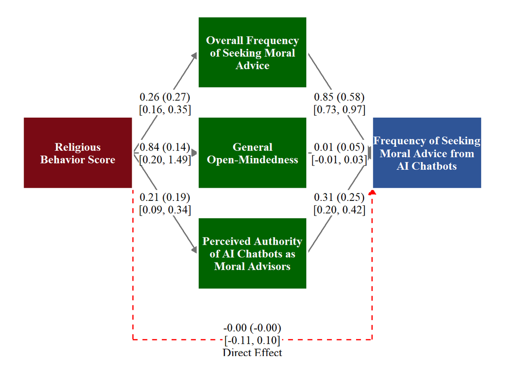

Figure 12: Study 1: Parallel Mediation — Self-Reported Religiosity → AI Moral Frequency

Table 22: Study 1: Full Parameter Estimates — Self-Reported Religiosity → AI Moral Frequency (Parallel Mediation)

| Path | b | β | SE | 95% CI LL | 95% CI UL | p |
| --- | --- | --- | --- | --- | --- | --- |
| Self-Reported Religiosity → Overall Frequency of Seeking Moral Advice | 0.256 | 0.271 | 0.049 | 0.161 | 0.351 | <.001 |
| Self-Reported Religiosity → General Open-Mindedness | 0.844 | 0.143 | 0.329 | 0.204 | 1.486 | 0.010 |
| Self-Reported Religiosity → Perceived Authority of AI Chatbots as Moral Advisors | 0.215 | 0.193 | 0.062 | 0.093 | 0.336 | <.001 |
| Overall Frequency of Seeking Moral Advice → AI Moral Frequency | 0.853 | 0.580 | 0.061 | 0.733 | 0.972 | <.001 |
| General Open-Mindedness → AI Moral Frequency | 0.011 | 0.048 | 0.009 | -0.007 | 0.029 | 0.215 |
| Perceived Authority of AI Chatbots as Moral Advisors → AI Moral Frequency | 0.310 | 0.249 | 0.057 | 0.196 | 0.422 | <.001 |
| Self-Reported Religiosity → AI Moral Frequency (direct) | -0.005 | -0.004 | 0.053 | -0.110 | 0.097 | 0.928 |
| Overall Frequency of Seeking Moral Advice ~~ General Open-Mindedness | 5.119 | 0.451 | 0.633 | 3.860 | 6.335 | <.001 |
| Overall Frequency of Seeking Moral Advice ~~ Perceived Authority of AI Chatbots as Moral Advisors | 0.791 | 0.372 | 0.124 | 0.547 | 1.031 | <.001 |
| General Open-Mindedness ~~ Perceived Authority of AI Chatbots as Moral Advisors | 3.143 | 0.230 | 0.729 | 1.665 | 4.526 | <.001 |
| Indirect via Overall Frequency of Seeking Moral Advice | 0.218 | 0.157 | 0.045 | 0.135 | 0.312 | <.001 |
| Indirect via General Open-Mindedness | 0.010 | 0.007 | 0.009 | -0.006 | 0.030 | 0.301 |
| Indirect via Perceived Authority of AI Chatbots as Moral Advisors | 0.067 | 0.048 | 0.024 | 0.025 | 0.120 | 0.006 |
| Total indirect effect | 0.294 | 0.212 | 0.057 | 0.188 | 0.409 | <.001 |

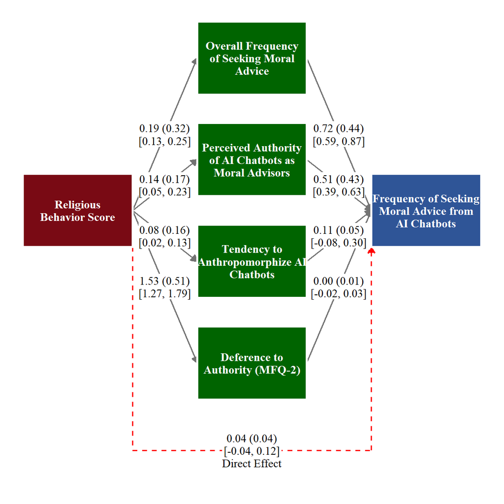

Figure 13: Study 2: Parallel Mediation — Self-Reported Religiosity → AI Moral Frequency

Table 23: Study 2: Full Parameter Estimates — Self-Reported Religiosity → AI Moral Frequency (Parallel Mediation)

| Path | b | β | SE | 95% CI LL | 95% CI UL | p |
| --- | --- | --- | --- | --- | --- | --- |
| Self-Reported Religiosity → Overall Frequency of Seeking Moral Advice | 0.189 | 0.322 | 0.032 | 0.126 | 0.252 | <.001 |
| Self-Reported Religiosity → Perceived Authority of AI Chatbots as Moral Advisors | 0.142 | 0.174 | 0.046 | 0.053 | 0.233 | 0.002 |
| Self-Reported Religiosity → Tendency to Anthropomorphize AI Chatbots | 0.078 | 0.162 | 0.028 | 0.025 | 0.133 | 0.005 |
| Self-Reported Religiosity → Deference to Authority (MFQ-2) | 1.530 | 0.511 | 0.133 | 1.271 | 1.790 | <.001 |
| Overall Frequency of Seeking Moral Advice → AI Moral Frequency | 0.724 | 0.435 | 0.070 | 0.588 | 0.866 | <.001 |
| Perceived Authority of AI Chatbots as Moral Advisors → AI Moral Frequency | 0.509 | 0.425 | 0.061 | 0.390 | 0.626 | <.001 |
| Tendency to Anthropomorphize AI Chatbots → AI Moral Frequency | 0.107 | 0.053 | 0.094 | -0.076 | 0.296 | 0.254 |
| Deference to Authority (MFQ-2) → AI Moral Frequency | 0.004 | 0.013 | 0.014 | -0.023 | 0.031 | 0.758 |
| Self-Reported Religiosity → AI Moral Frequency (direct) | 0.042 | 0.043 | 0.042 | -0.042 | 0.125 | 0.316 |
| Overall Frequency of Seeking Moral Advice ~~ Perceived Authority of AI Chatbots as Moral Advisors | 0.775 | 0.358 | 0.124 | 0.527 | 1.015 | <.001 |
| Overall Frequency of Seeking Moral Advice ~~ Tendency to Anthropomorphize AI Chatbots | 0.353 | 0.274 | 0.075 | 0.204 | 0.502 | <.001 |
| Overall Frequency of Seeking Moral Advice ~~ Deference to Authority (MFQ-2) | 1.565 | 0.225 | 0.366 | 0.869 | 2.309 | <.001 |
| Perceived Authority of AI Chatbots as Moral Advisors ~~ Tendency to Anthropomorphize AI Chatbots | 1.038 | 0.557 | 0.103 | 0.830 | 1.231 | <.001 |
| Perceived Authority of AI Chatbots as Moral Advisors ~~ Deference to Authority (MFQ-2) | 2.114 | 0.210 | 0.574 | 0.969 | 3.251 | <.001 |
| Tendency to Anthropomorphize AI Chatbots ~~ Deference to Authority (MFQ-2) | 1.657 | 0.277 | 0.354 | 0.967 | 2.346 | <.001 |
| Indirect via Overall Frequency of Seeking Moral Advice | 0.137 | 0.140 | 0.028 | 0.084 | 0.194 | <.001 |
| Indirect via Perceived Authority of AI Chatbots as Moral Advisors | 0.072 | 0.074 | 0.025 | 0.026 | 0.123 | 0.003 |
| Indirect via Tendency to Anthropomorphize AI Chatbots | 0.008 | 0.009 | 0.009 | -0.006 | 0.028 | 0.326 |
| Indirect via Deference to Authority (MFQ-2) | 0.007 | 0.007 | 0.021 | -0.036 | 0.049 | 0.760 |
| Total indirect effect | 0.224 | 0.229 | 0.047 | 0.134 | 0.319 | <.001 |

The Study 1 parallel mediation model explained 54.8% of the variance in frequency of seeking moral advice from AI chatbots (*R²* = 0.548). The total indirect effect was *b* = 0.294 (95% CI [0.188, 0.409]), with a residual direct effect of *b* = -0.005 (*p* =0.928). In Study 2, the model explained 58.7% of the variance (*R²* = 0.587), with a total indirect effect of *b* = 0.224 (95% CI [0.134, 0.319]) and a direct effect of *b* = 0.042 (*p* =0.316).

### 8.3.4 Religious Behavior Score → AI Moral Interest — Path Diagrams

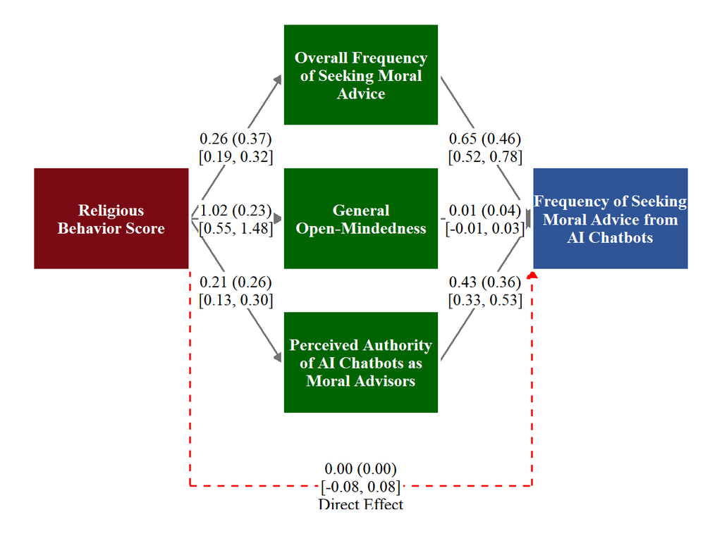

Figure 14: Study 1: Parallel Mediation — Religious Behavior Score → AI Moral Interest

Table 24: Study 1: Full Parameter Estimates — Religious Behavior Score → AI Moral Interest (Parallel Mediation)

| Path | b | β | SE | 95% CI LL | 95% CI UL | p |
| --- | --- | --- | --- | --- | --- | --- |
| Religious Behavior Score → Overall Frequency of Seeking Moral Advice | 0.256 | 0.369 | 0.035 | 0.186 | 0.325 | <.001 |
| Religious Behavior Score → General Open-Mindedness | 1.015 | 0.234 | 0.238 | 0.546 | 1.476 | <.001 |
| Religious Behavior Score → Perceived Authority of AI Chatbots as Moral Advisors | 0.215 | 0.262 | 0.043 | 0.130 | 0.300 | <.001 |
| Overall Frequency of Seeking Moral Advice → AI Moral Interest | 0.651 | 0.461 | 0.066 | 0.522 | 0.780 | <.001 |
| General Open-Mindedness → AI Moral Interest | 0.010 | 0.043 | 0.009 | -0.008 | 0.028 | 0.302 |
| Perceived Authority of AI Chatbots as Moral Advisors → AI Moral Interest | 0.431 | 0.361 | 0.053 | 0.328 | 0.535 | <.001 |
| Religious Behavior Score → AI Moral Interest (direct) | 0.000 | 0.000 | 0.039 | -0.077 | 0.077 | 0.992 |
| Overall Frequency of Seeking Moral Advice ~~ General Open-Mindedness | 4.553 | 0.423 | 0.572 | 3.424 | 5.690 | <.001 |
| Overall Frequency of Seeking Moral Advice ~~ Perceived Authority of AI Chatbots as Moral Advisors | 0.691 | 0.342 | 0.117 | 0.460 | 0.919 | <.001 |
| General Open-Mindedness ~~ Perceived Authority of AI Chatbots as Moral Advisors | 2.671 | 0.202 | 0.711 | 1.252 | 4.022 | <.001 |
| Indirect via Overall Frequency of Seeking Moral Advice | 0.167 | 0.170 | 0.029 | 0.114 | 0.229 | <.001 |
| Indirect via General Open-Mindedness | 0.010 | 0.010 | 0.010 | -0.008 | 0.033 | 0.344 |
| Indirect via Perceived Authority of AI Chatbots as Moral Advisors | 0.093 | 0.094 | 0.022 | 0.054 | 0.140 | <.001 |
| Total indirect effect | 0.270 | 0.275 | 0.038 | 0.197 | 0.345 | <.001 |

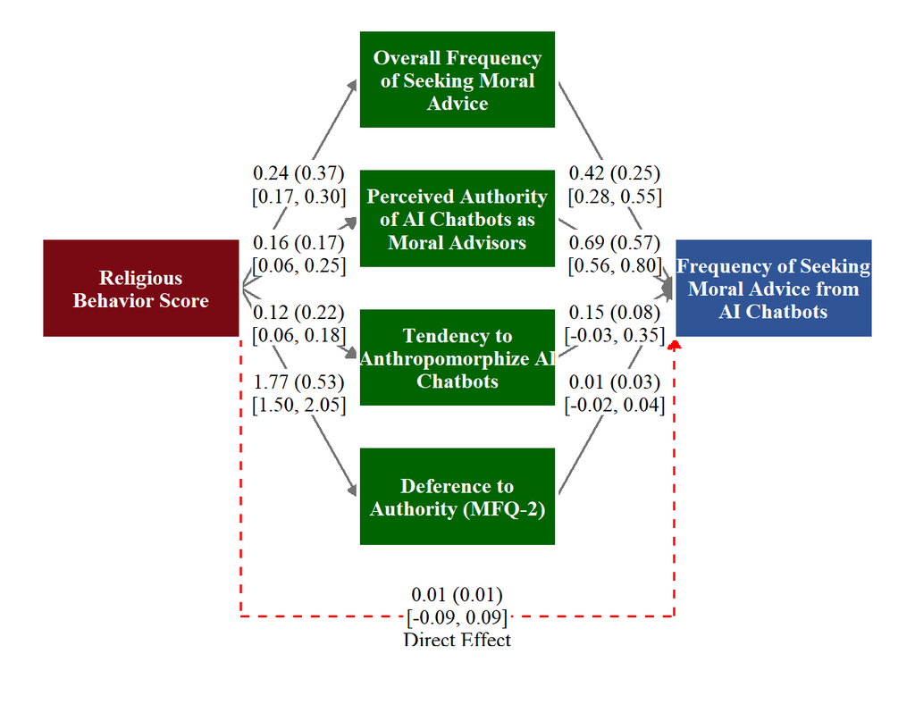

Figure 15: Study 2: Parallel Mediation — Religious Behavior Score → AI Moral Interest

Table 25: Study 2: Full Parameter Estimates — Religious Behavior Score → AI Moral Interest (Parallel Mediation)

| Path | b | β | SE | 95% CI LL | 95% CI UL | p |
| --- | --- | --- | --- | --- | --- | --- |
| Religious Behavior Score → Overall Frequency of Seeking Moral Advice | 0.239 | 0.367 | 0.034 | 0.172 | 0.305 | <.001 |
| Religious Behavior Score → Perceived Authority of AI Chatbots as Moral Advisors | 0.158 | 0.175 | 0.048 | 0.061 | 0.251 | 0.001 |
| Religious Behavior Score → Tendency to Anthropomorphize AI Chatbots | 0.120 | 0.223 | 0.030 | 0.061 | 0.177 | <.001 |
| Religious Behavior Score → Deference to Authority (MFQ-2) | 1.775 | 0.535 | 0.143 | 1.495 | 2.054 | <.001 |
| Overall Frequency of Seeking Moral Advice → AI Moral Interest | 0.416 | 0.251 | 0.070 | 0.283 | 0.553 | <.001 |
| Perceived Authority of AI Chatbots as Moral Advisors → AI Moral Interest | 0.686 | 0.574 | 0.061 | 0.560 | 0.803 | <.001 |
| Tendency to Anthropomorphize AI Chatbots → AI Moral Interest | 0.151 | 0.075 | 0.095 | -0.026 | 0.348 | 0.113 |
| Deference to Authority (MFQ-2) → AI Moral Interest | 0.011 | 0.035 | 0.015 | -0.016 | 0.040 | 0.439 |
| Religious Behavior Score → AI Moral Interest (direct) | 0.006 | 0.006 | 0.046 | -0.085 | 0.095 | 0.889 |
| Overall Frequency of Seeking Moral Advice ~~ Perceived Authority of AI Chatbots as Moral Advisors | 0.756 | 0.355 | 0.121 | 0.516 | 0.990 | <.001 |
| Overall Frequency of Seeking Moral Advice ~~ Tendency to Anthropomorphize AI Chatbots | 0.312 | 0.249 | 0.075 | 0.166 | 0.460 | <.001 |
| Overall Frequency of Seeking Moral Advice ~~ Deference to Authority (MFQ-2) | 1.292 | 0.193 | 0.368 | 0.588 | 2.020 | <.001 |
| Perceived Authority of AI Chatbots as Moral Advisors ~~ Tendency to Anthropomorphize AI Chatbots | 1.017 | 0.552 | 0.104 | 0.810 | 1.216 | <.001 |
| Perceived Authority of AI Chatbots as Moral Advisors ~~ Deference to Authority (MFQ-2) | 2.058 | 0.208 | 0.565 | 0.931 | 3.166 | <.001 |
| Tendency to Anthropomorphize AI Chatbots ~~ Deference to Authority (MFQ-2) | 1.398 | 0.241 | 0.345 | 0.725 | 2.079 | <.001 |
| Indirect via Overall Frequency of Seeking Moral Advice | 0.099 | 0.092 | 0.022 | 0.059 | 0.147 | <.001 |
| Indirect via Perceived Authority of AI Chatbots as Moral Advisors | 0.108 | 0.100 | 0.034 | 0.042 | 0.175 | 0.001 |
| Indirect via Tendency to Anthropomorphize AI Chatbots | 0.018 | 0.017 | 0.012 | -0.003 | 0.046 | 0.148 |
| Indirect via Deference to Authority (MFQ-2) | 0.020 | 0.019 | 0.026 | -0.029 | 0.073 | 0.444 |
| Total indirect effect | 0.246 | 0.228 | 0.052 | 0.144 | 0.347 | <.001 |

The Study 1 parallel mediation model explained 50.6% of the variance in interest in seeking moral advice from AI chatbots (*R²* = 0.506). The total indirect effect was *b* = 0.27 (95% CI [0.197, 0.345]), with a residual direct effect of *b* = 0 (*p* =0.992). In Study 2, the model explained 59.3% of the variance (*R²* = 0.593), with a total indirect effect of *b* = 0.246 (95% CI [0.144, 0.347]) and a direct effect of *b* = 0.006 (*p* =0.889).

### 8.3.5 Self-Reported Religiosity → AI Moral Interest — Path Diagrams

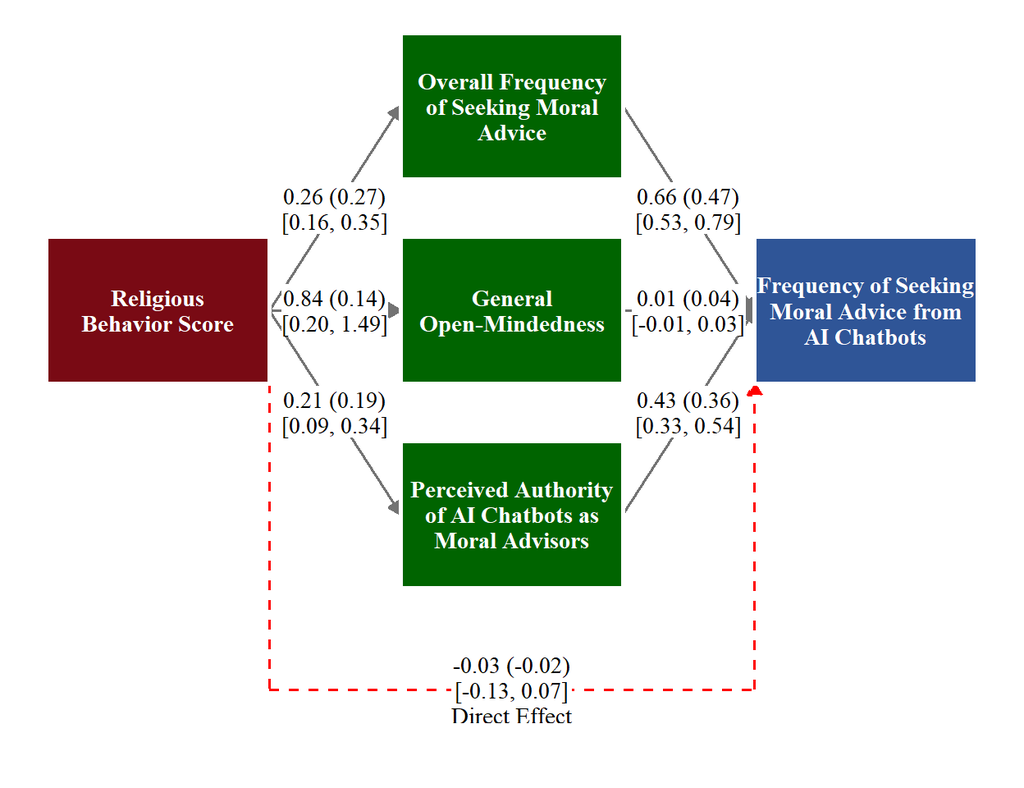

Figure 16: Study 1: Parallel Mediation — Self-Reported Religiosity → AI Moral Interest

Table 26: Study 1: Full Parameter Estimates — Self-Reported Religiosity → AI Moral Interest (Parallel Mediation)

| Path | b | β | SE | 95% CI LL | 95% CI UL | p |
| --- | --- | --- | --- | --- | --- | --- |
| Self-Reported Religiosity → Overall Frequency of Seeking Moral Advice | 0.256 | 0.271 | 0.049 | 0.160 | 0.350 | <.001 |
| Self-Reported Religiosity → General Open-Mindedness | 0.844 | 0.143 | 0.328 | 0.204 | 1.485 | 0.010 |
| Self-Reported Religiosity → Perceived Authority of AI Chatbots as Moral Advisors | 0.215 | 0.193 | 0.062 | 0.094 | 0.336 | <.001 |
| Overall Frequency of Seeking Moral Advice → AI Moral Interest | 0.659 | 0.467 | 0.066 | 0.532 | 0.789 | <.001 |
| General Open-Mindedness → AI Moral Interest | 0.010 | 0.044 | 0.009 | -0.008 | 0.029 | 0.296 |
| Perceived Authority of AI Chatbots as Moral Advisors → AI Moral Interest | 0.434 | 0.363 | 0.053 | 0.330 | 0.538 | <.001 |
| Self-Reported Religiosity → AI Moral Interest (direct) | -0.030 | -0.023 | 0.050 | -0.129 | 0.066 | 0.548 |
| Overall Frequency of Seeking Moral Advice ~~ General Open-Mindedness | 5.119 | 0.451 | 0.635 | 3.860 | 6.338 | <.001 |
| Overall Frequency of Seeking Moral Advice ~~ Perceived Authority of AI Chatbots as Moral Advisors | 0.791 | 0.372 | 0.124 | 0.547 | 1.031 | <.001 |
| General Open-Mindedness ~~ Perceived Authority of AI Chatbots as Moral Advisors | 3.143 | 0.230 | 0.729 | 1.666 | 4.532 | <.001 |
| Indirect via Overall Frequency of Seeking Moral Advice | 0.168 | 0.126 | 0.037 | 0.102 | 0.245 | <.001 |
| Indirect via General Open-Mindedness | 0.008 | 0.006 | 0.009 | -0.006 | 0.031 | 0.380 |
| Indirect via Perceived Authority of AI Chatbots as Moral Advisors | 0.093 | 0.070 | 0.030 | 0.040 | 0.155 | 0.002 |
| Total indirect effect | 0.270 | 0.203 | 0.054 | 0.169 | 0.375 | <.001 |

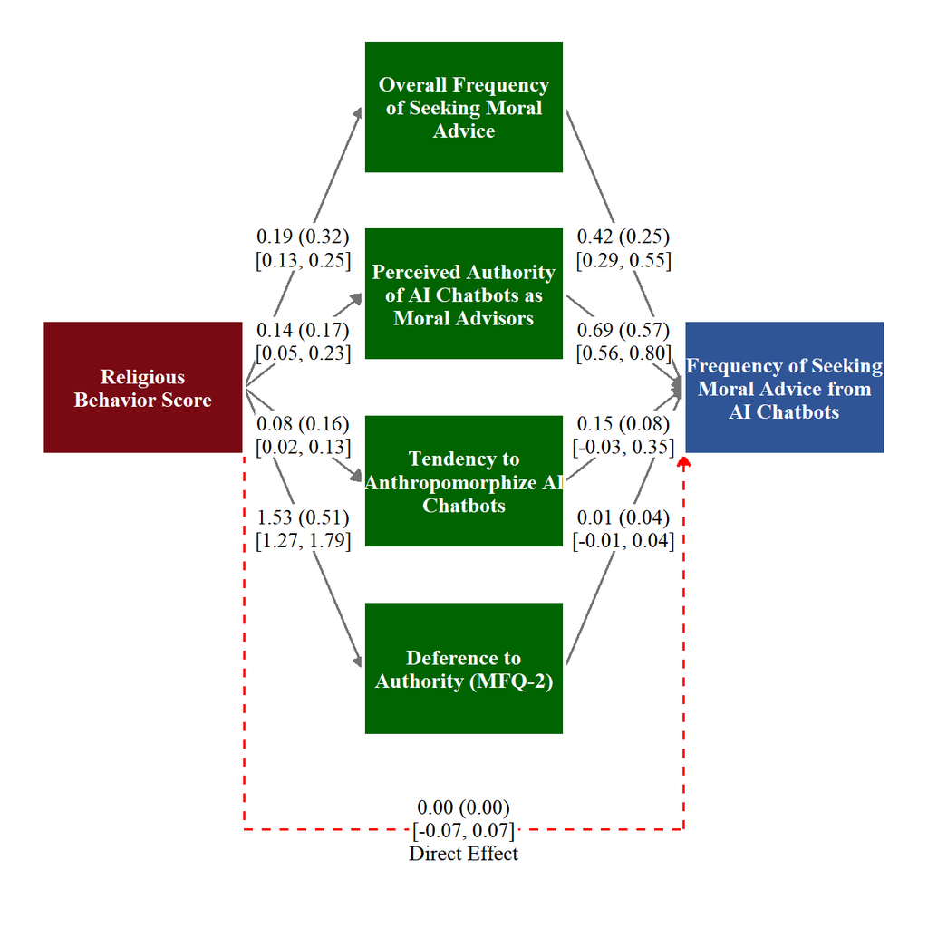

Figure 17: Study 2: Parallel Mediation — Self-Reported Religiosity → AI Moral Interest

Table 27: Study 2: Full Parameter Estimates — Self-Reported Religiosity → AI Moral Interest (Parallel Mediation)

| Path | b | β | SE | 95% CI LL | 95% CI UL | p |
| --- | --- | --- | --- | --- | --- | --- |
| Self-Reported Religiosity → Overall Frequency of Seeking Moral Advice | 0.189 | 0.322 | 0.032 | 0.126 | 0.252 | <.001 |
| Self-Reported Religiosity → Perceived Authority of AI Chatbots as Moral Advisors | 0.142 | 0.174 | 0.046 | 0.053 | 0.233 | 0.002 |
| Self-Reported Religiosity → Tendency to Anthropomorphize AI Chatbots | 0.078 | 0.162 | 0.028 | 0.025 | 0.133 | 0.005 |
| Self-Reported Religiosity → Deference to Authority (MFQ-2) | 1.530 | 0.511 | 0.133 | 1.269 | 1.790 | <.001 |
| Overall Frequency of Seeking Moral Advice → AI Moral Interest | 0.418 | 0.252 | 0.068 | 0.286 | 0.550 | <.001 |
| Perceived Authority of AI Chatbots as Moral Advisors → AI Moral Interest | 0.685 | 0.574 | 0.061 | 0.560 | 0.800 | <.001 |
| Tendency to Anthropomorphize AI Chatbots → AI Moral Interest | 0.152 | 0.075 | 0.096 | -0.027 | 0.350 | 0.113 |
| Deference to Authority (MFQ-2) → AI Moral Interest | 0.012 | 0.037 | 0.014 | -0.015 | 0.039 | 0.394 |
| Self-Reported Religiosity → AI Moral Interest (direct) | 0.002 | 0.002 | 0.037 | -0.071 | 0.072 | 0.953 |
| Overall Frequency of Seeking Moral Advice ~~ Perceived Authority of AI Chatbots as Moral Advisors | 0.775 | 0.358 | 0.124 | 0.527 | 1.016 | <.001 |
| Overall Frequency of Seeking Moral Advice ~~ Tendency to Anthropomorphize AI Chatbots | 0.353 | 0.274 | 0.075 | 0.205 | 0.503 | <.001 |
| Overall Frequency of Seeking Moral Advice ~~ Deference to Authority (MFQ-2) | 1.565 | 0.225 | 0.366 | 0.868 | 2.307 | <.001 |
| Perceived Authority of AI Chatbots as Moral Advisors ~~ Tendency to Anthropomorphize AI Chatbots | 1.038 | 0.557 | 0.103 | 0.831 | 1.232 | <.001 |
| Perceived Authority of AI Chatbots as Moral Advisors ~~ Deference to Authority (MFQ-2) | 2.114 | 0.210 | 0.573 | 0.970 | 3.251 | <.001 |
| Tendency to Anthropomorphize AI Chatbots ~~ Deference to Authority (MFQ-2) | 1.657 | 0.277 | 0.354 | 0.978 | 2.346 | <.001 |
| Indirect via Overall Frequency of Seeking Moral Advice | 0.079 | 0.081 | 0.019 | 0.045 | 0.122 | <.001 |
| Indirect via Perceived Authority of AI Chatbots as Moral Advisors | 0.097 | 0.100 | 0.032 | 0.036 | 0.162 | 0.003 |
| Indirect via Tendency to Anthropomorphize AI Chatbots | 0.012 | 0.012 | 0.009 | -0.002 | 0.034 | 0.186 |
| Indirect via Deference to Authority (MFQ-2) | 0.018 | 0.019 | 0.022 | -0.022 | 0.061 | 0.401 |
| Total indirect effect | 0.206 | 0.212 | 0.047 | 0.115 | 0.297 | <.001 |

The Study 1 parallel mediation model explained 50.7% of the variance in interest in seeking moral advice from AI chatbots (*R²* = 0.507). The total indirect effect was *b* = 0.27 (95% CI [0.169, 0.375]), with a residual direct effect of *b* = -0.03 (*p* =0.548). In Study 2, the model explained 59.3% of the variance (*R²* = 0.593), with a total indirect effect of *b* = 0.206 (95% CI [0.115, 0.297]) and a direct effect of *b* = 0.002 (*p* =0.953).

# 9 Moderation Analyses

The main body (Question 4) tested whether access to moral advice sources moderates the Religious Behavior Score → frequency relationship. Here we report supplementary moderation analyses for three additional predictor–outcome combinations: Self-Reported Religiosity → Frequency, Religious Behavior Score → Interest, and Self-Reported Religiosity → Interest. For each, we test both AI chatbot access and overall access to non-AI sources as moderators (Study 2 only).

## 9.1 Self-Reported Religiosity × Access → AI Moral Frequency

Table 28: Supplementary Moderation: Self-Reported Religiosity × Access → Frequency of Seeking Moral Advice From AI Chatbots

| Parameter | b | SE | t | p |
| --- | --- | --- | --- | --- |
| Model: Model 1: Moderator = AI Chatbot Access |  |  |  |  |
| Constant | 0.29 | 0.65 | 0.45 | 0.652 |
| Self-Reported Religiosity (X) | 0.13 | 0.20 | 0.65 | 0.515 |
| AI Chatbot Access (W) | 0.36 | 0.11 | 3.23 | 0.001 |
| X × W | 0.01 | 0.03 | 0.40 | 0.686 |
| Model: Model 2: Moderator = Overall Source Access |  |  |  |  |
| Constant | 1.61 | 0.92 | 1.76 | 0.079 |
| Self-Reported Religiosity (X) | -0.19 | 0.29 | -0.66 | 0.511 |
| Overall Source Access (W) | 0.15 | 0.20 | 0.77 | 0.443 |
| X × W | 0.08 | 0.06 | 1.45 | 0.149 |

Model 1: R² = 0.151, Adj. R² = 0.143, F(3, 343) = 20.30, p <.001. Model 2: R² = 0.103, Adj. R² = 0.095, F(3, 343) = 13.14, p <.001. Study 2 only. (N = 348).

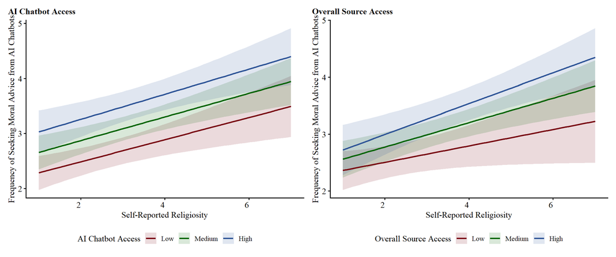

Figure 18: Self-Reported Religiosity → Frequency of Seeking Moral Advice From AI Chatbots, Moderated by Access

AI chatbot access did not significantly moderate the Self-Reported Religiosity → frequency relationship (*b* = 0.01, *t*(343) = 0.4, *p* =0.686). Overall access to non-AI sources did not significantly moderate this relationship (*b* = 0.08, *t*(343) = 1.45, *p* =0.149).

## 9.2 Religious Behavior Score × Access → AI Moral Interest

Table 29: Supplementary Moderation: Religious Behavior Score × Access → Interest in Seeking Moral Advice From AI Chatbots

| Parameter | b | SE | t | p |
| --- | --- | --- | --- | --- |
| Model: Model 1: Moderator = AI Chatbot Access |  |  |  |  |
| Constant | 0.81 | 0.72 | 1.13 | 0.258 |
| Religious Behavior Score (X) | -0.05 | 0.21 | -0.24 | 0.814 |
| AI Chatbot Access (W) | 0.32 | 0.12 | 2.57 | 0.011 |
| X × W | 0.04 | 0.04 | 1.19 | 0.234 |
| Model: Model 2: Moderator = Overall Source Access |  |  |  |  |
| Constant | 2.08 | 1.00 | 2.08 | 0.038 |
| Religious Behavior Score (X) | -0.39 | 0.31 | -1.26 | 0.209 |
| Overall Source Access (W) | 0.12 | 0.21 | 0.54 | 0.590 |
| X × W | 0.12 | 0.06 | 1.92 | 0.056 |

Model 1: R² = 0.153, Adj. R² = 0.146, F(3, 343) = 20.72, p <.001. Model 2: R² = 0.100, Adj. R² = 0.092, F(3, 343) = 12.68, p <.001. Study 2 only. (N = 348).

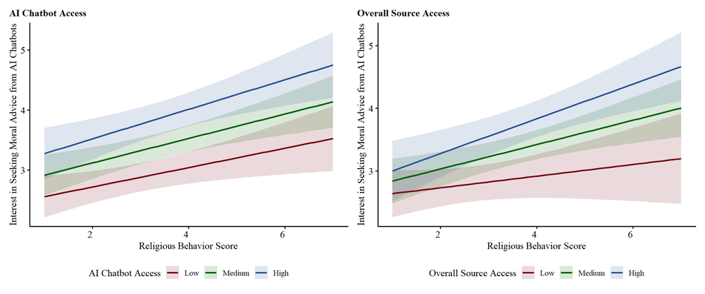

Figure 19: Religious Behavior Score → Interest in Seeking Moral Advice From AI Chatbots, Moderated by Access

AI chatbot access did not significantly moderate the Religious Behavior Score → interest relationship (*b* = 0.04, *t*(343) = 1.19, *p* =0.234). Overall access to non-AI sources did not significantly moderate this relationship (*b* = 0.12, *t*(343) = 1.92, *p* =0.056).

## 9.3 Self-Reported Religiosity × Access → AI Moral Interest

Table 30: Supplementary Moderation: Self-Reported Religiosity × Access → Interest in Seeking Moral Advice From AI Chatbots

| Parameter | b | SE | t | p |
| --- | --- | --- | --- | --- |
| Model: Model 1: Moderator = AI Chatbot Access |  |  |  |  |
| Constant | 0.64 | 0.65 | 0.99 | 0.322 |
| Self-Reported Religiosity (X) | 0.02 | 0.21 | 0.08 | 0.938 |
| AI Chatbot Access (W) | 0.38 | 0.11 | 3.41 | <.001 |
| X × W | 0.02 | 0.03 | 0.67 | 0.501 |
| Model: Model 2: Moderator = Overall Source Access |  |  |  |  |
| Constant | 1.80 | 0.92 | 1.95 | 0.052 |
| Self-Reported Religiosity (X) | -0.30 | 0.29 | -1.05 | 0.294 |
| Overall Source Access (W) | 0.22 | 0.20 | 1.09 | 0.276 |
| X × W | 0.09 | 0.06 | 1.60 | 0.111 |

Model 1: R² = 0.142, Adj. R² = 0.134, F(3, 343) = 18.88, p <.001. Model 2: R² = 0.089, Adj. R² = 0.081, F(3, 343) = 11.13, p <.001. Study 2 only. (N = 348).

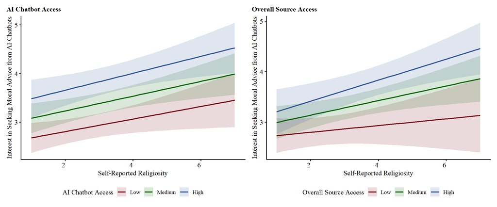

Figure 20: Self-Reported Religiosity → Interest in Seeking Moral Advice From AI Chatbots, Moderated by Access

AI chatbot access did not significantly moderate the Self-Reported Religiosity → interest relationship (*b* = 0.02, *t*(343) = 0.67, *p* =0.501). Overall access to non-AI sources did not significantly moderate this relationship (*b* = 0.09, *t*(343) = 1.6, *p* =0.111).

## References

Rosseel, Yves. 2012. “Lavaan: An R Package for Structural Equation Modeling.” *Journal of Statistical Software* 48 (2): 1–36. https://doi.org/10.18637/jss.v048.i02.